# Data Analysis Notebook

```r
#Authors: [Sydney Stanton, Carter Zborowski]

#Author Date: 06/09/2025
#Purpose: The purpose of this notebook is to house all data set transformation, cleansing, visualization, statistical analysis, and note-taking for the 2025 CU Athletic Department Sports Science Internship Program..

#LAST UPDATED: 07/01/2025

#Including helpful libraries
library(tidyverse)
library(readxl)
library(aod)
library(tidyverse)
library(tidyr)
library(dplyr)
library(ggplot2)
library(lubridate)
```

```r
#load all of the useful datasets
ACWR <- read_csv('data-sets/data-sets-uncompressed/ACWR- Catapult FB.csv')
catapult <- read_csv('data-sets/data-sets-uncompressed/Catapult Session - Outdoor FB.csv')
incident <- read_csv('data-sets/data-sets-uncompressed/Incident Report FB.csv')
perfnorm <- read_csv('data-sets/data-sets-uncompressed/Performance Normative Data FB.csv')
perfrisk <- read_csv('data-sets/data-sets-uncompressed/Performance Risk Assessment FB.csv')
riskstatus <- read_csv('data-sets/data-sets-uncompressed/Soft Tissue Risk Status Report FB.csv')
strengthtest <- read_csv('data-sets/data-sets-uncompressed/Strength Testing Data FB.csv')
VALD <- read_csv('data-sets/data-sets-uncompressed/VALD - Performance Test FB.csv')
wellness <- read_csv('data-sets/data-sets-uncompressed/Wellness Report FB.csv')
positional <- read_csv('data-sets/data-sets-uncompressed/Positional Performance Normative.csv')
positions <- read_csv('data-sets/data-sets-uncompressed/deid_pos.csv')
perfnorm_byposition <- read_csv('data-sets/data-sets-uncompressed/Positional Performance Normative.csv')
player_byposition <- read_csv('data-sets/data-sets-uncompressed/deid_pos.csv')
```

# Cleaning Datasets

## 1. ACWR

```r
#refined ACWR dataset
ACWR <- ACWR %>%
  filter(Sport=="FOOTBALL")
Acwr <- subset(ACWR,select=c("anon_id","Date","Position","Total.Player.Load","Acute.Total.Acceleration.Load.EWMA","Acceleration.Load.ACWR","Acceleration.Load.EWMA.ACWR","Player.Load.ACWR","Total.Distance.ACWR","Month","Year"))

#cut back to last 12 months (last year)
Acwr$Date <- mdy(Acwr$Date)
current_date <- Sys.Date()
start_date <- current_date- months(12)

acwr_merge <- Acwr %>%
  select(-c('Month', 'Year')) %>%
  na.omit() %>%
  mutate(Date = as.Date(Date, format = '%m/%d/%Y'))

filtered_Acwr <- Acwr %>%
  filter(Date >= start_date) %>%
  na.omit() %>%
  group_by(anon_id, Month, Year, Position) %>%
  summarise(Total.Player.Load = mean(Total.Player.Load, na.rm = TRUE),
            Acceleration.Load.EWMA.ACWR = mean(Acceleration.Load.EWMA.ACWR, na.rm = TRUE),
            Acceleration.Load.ACWR = mean(Acceleration.Load.ACWR, na.rm = TRUE),
            Player.Load.ACWR = mean(Player.Load.ACWR, na.rm = TRUE),
            Acute.Total.Acceleration.Load.EWMA=mean(Acute.Total.Acceleration.Load.EWMA, na.rm=TRUE),
            Total.Distance.ACWR = mean(Total.Distance.ACWR, na.rm = TRUE)) %>%
  ungroup()
```

## 2. Catapult

```r
#refined catapult session outdoor dataset
catapult <- catapult %>%
filter(Sport=="FOOTBALL")

catapult <- subset(catapult,select=c("anon_id", "Position", "Date", "High.Speed.Distance", "Very.High.Speed.Distance", "Maximum.Velocity", "Average.Velocity","IMA.Accel.Low", "IMA.Decel.Low", "IMA.Accel.Medium", "IMA.Decel.Medium", "IMA.Accel.High", "IMA.Decel.High", "IMA.Accel.Total", "IMA.Decel.Total", "Explosive.Efforts","Total.Player.Load","Average.IMA","Max.Acceleration","Max.Deceleration"))

catapult$Date <- mdy(catapult$Date)
current_date <- Sys.Date()
start_date <- current_date- months(12)

filtered_catapult <- catapult %>%
  filter(Date >= start_date) %>%
  group_by(anon_id, Date, Position) %>%
  summarise(High.Speed.Distance = sum(High.Speed.Distance, na.rm = TRUE),
            Very.High.Speed.Distance = sum(Very.High.Speed.Distance, na.rm = TRUE),
            Max.Acceleration= mean(Max.Acceleration,na.rm=TRUE),
            Max.Deceleration= mean(Max.Deceleration, na.rm=TRUE),
            Maximum.Velocity = mean(Maximum.Velocity, na.rm = TRUE),
            Average.Velocity = mean(Average.Velocity, na.rm = TRUE),
            Average.IMA= mean(Average.IMA, na.rm=TRUE),
            IMA.Accel.Low = sum(IMA.Accel.Low, na.rm = TRUE),
            IMA.Decel.Low = sum(IMA.Decel.Low, na.rm = TRUE),
            IMA.Accel.Medium = sum(IMA.Accel.Medium, na.rm = TRUE),
            IMA.Decel.Medium = sum(IMA.Decel.Medium, na.rm = TRUE),
            IMA.Accel.High = sum(IMA.Accel.High, na.rm = TRUE),
            IMA.Decel.High = sum(IMA.Decel.High, na.rm = TRUE),
            IMA.Accel.Total = sum(IMA.Accel.Total, na.rm = TRUE),
            IMA.Decel.Total = sum(IMA.Decel.Total, na.rm = TRUE),
            Explosive.Efforts = sum(Explosive.Efforts, na.rm = TRUE))
catapult_merge <- catapult %>%
  mutate(Date = as.Date(Date, format = '%m/%d/%Y')) %>%
  group_by(anon_id, Date, Position) %>%
  summarise(High.Speed.Distance = sum(High.Speed.Distance, na.rm = TRUE),
            Very.High.Speed.Distance = sum(Very.High.Speed.Distance, na.rm = TRUE),
            Maximum.Velocity = mean(Maximum.Velocity, na.rm = TRUE),
            Average.Velocity = mean(Average.Velocity, na.rm = TRUE),
            IMA.Accel.Low = sum(IMA.Accel.Low, na.rm = TRUE),
            IMA.Decel.Low = sum(IMA.Decel.Low, na.rm = TRUE),
            IMA.Accel.Medium = sum(IMA.Accel.Medium, na.rm = TRUE),
            IMA.Decel.Medium = sum(IMA.Decel.Medium, na.rm = TRUE),
            IMA.Accel.High = sum(IMA.Accel.High, na.rm = TRUE),
            IMA.Decel.High = sum(IMA.Decel.High, na.rm = TRUE),
            IMA.Accel.Total = sum(IMA.Accel.Total, na.rm = TRUE),
            IMA.Decel.Total = sum(IMA.Decel.Total, na.rm = TRUE),
            Explosive.Efforts = sum(Explosive.Efforts, na.rm = TRUE),
            Total.Player.Load = sum(Total.Player.Load, na.rm = TRUE),
            Average.IMA = mean(Average.IMA, na.rm = TRUE),
            Max.Acceleration = max(Max.Acceleration, na.rm = TRUE),
            Max.Deceleration = min(Max.Deceleration, na.rm = TRUE))
```

```r
#IMAs are counted variable so sum these
mean(catapult$High.Speed.Distance,na.rm=TRUE)
```

```
[1] 30.61581
```

```r
mean(catapult$Maximum.Velocity,na.rm=TRUE)
```

```
[1] 10.39801
```

```r
#mean(catapult$Total.Player.Load,na.rm=TRUE) convert to as.numeric

#Maximum + average of the maximum & average velocity (given to us)
max(catapult$Maximum.Velocity,na.rm=TRUE)
```

```
[1] 49.084
```

```r
mean(catapult$Average.Velocity,na.rm=TRUE)
```

```
[1] 30.66589
```

## 3. Incident

```r
#sort out any non football values + etc
incident <- incident %>%
filter(Sport=="FOOTBALL") %>%
filter(Incident.Type=="Injury") %>%
filter(Result.of.Sport.Participation=="Yes")

filtered_incident <- subset(incident,select=c("anon_id", "Position", "Date.of.Injury...Onset.of.symptoms", "Side", "Body.Part", "Tissue.Type", "Pathology.Type", "OSICS14.Code", "OSICS10.Code", "OSICS10.Diagnosis", "Final.Diagnosis", "Result.of.Sport.Participation", "Recurrence.of.Injury", "Injury.Prognosis", "General.Mechanism", "Specific.Mechanism", "FinalDiagnosisIncidentDate", "Total.Time.Injured", "Month", "Year","Incident.Type"))[-c(1167,1168),]
```

```r
#binary to determine if incident is HSI or not
incident$HSI <- ifelse(incident$OSICS14.Code %in% c("TMI","TMB","TMS"),1,0)

#overall # of HSI incidences from filtered dataset
sum(incident$HSI)   #OF 1703 observations 28 of them an HSI injury occured
```

```
[1] 28
```

```r
lower_body <- c("Thigh", "Ankle", "Lower Leg", "Knee", "Foot", "Groin/hip")
hamstring_OSICS14 <- c('TM1', 'TMB', 'TMS')

#filter for just hamstring related injuries and get rid of duplicate observations
incident_HSI <- filtered_incident %>%
  filter(OSICS14.Code %in% hamstring_OSICS14) %>%  #need other injuries to compare to w/ HSI
  group_by(anon_id, Date.of.Injury...Onset.of.symptoms) %>%
  mutate(Total.Time.Injured = sum(Total.Time.Injured, na.rm = TRUE),
         Date = as.Date(Date.of.Injury...Onset.of.symptoms, format = '%m/%d/%Y')) %>%
  ungroup() %>%
  group_by(across(everything())) %>%
  summarise(.groups = 'drop')

#binary to determine if incident is HSI or not
incident_HSI$HSI <- ifelse(incident_HSI$OSICS14.Code %in% c("TMI","TMB","TMS"),1,0)

#filter for just injuries in the lower body and get rid of duplicate observations
incident_lower <- filtered_incident %>%
  filter(Body.Part %in% lower_body) %>%
  group_by(anon_id, Date.of.Injury...Onset.of.symptoms) %>%
  mutate(Total.Time.Injured = sum(Total.Time.Injured, na.rm = TRUE),
         Date = as.Date(Date.of.Injury...Onset.of.symptoms, format = '%m/%d/%Y')) %>%
  ungroup() %>%
  group_by(across(everything())) %>%
  summarise(.groups = 'drop')

#creating a list of players who experienced HSI
players_HSI <- unique(incident_HSI$anon_id)

#consolidate same players into one observation
incident_HSI2 <- incident_HSI %>%
  mutate(Date = as.Date(Date.of.Injury...Onset.of.symptoms, format = '%m/%d/%Y')) %>%
  arrange(Date) %>%
  group_by(anon_id) %>%
  summarize(Body.Part, Outcome = paste0(Date, collapse = " and ")) %>%
  separate(Outcome, c('Injury.1', 'Injury.2', 'Injury.3', 'Injury.4'), sep = ' and ')
```

[output not shown]

```r
#cut back to last year
incident_HSI$Date <- mdy(incident_HSI$Date)
current_date <- Sys.Date()
start_date <- current_date- months(12)
incident_HSI_1yr <- incident_HSI %>%
  filter(Date >= start_date)
```

```r
#overall # of HSI incidences from filtered dataset
sum(incident_HSI$HSI)
```

```
[1] 4
```

## 4. Performance Normative data

```r
filtered_perfnorm <- subset(perfnorm,select=c("anon_id","Date","Position","Nordic.Average","Nordic.Imbalance..","Adduction.Abduction.Ratio","Eccentric.Peak.Power...Relative","Jump.Height","Modified.RSI"))

#cut back to last year
filtered_perfnorm$Date <- mdy(filtered_perfnorm$Date)
current_date <- Sys.Date()
start_date <- current_date- months(12)

perfnorm_merge <- filtered_perfnorm %>%
  filter(Date >= start_date) %>%
  select(-Position) %>%
  #group_by(anon_id, Date) %>%
  mutate(Date = as.Date(Date, format = '%m/%d/%Y')) %>%
  na.omit()
```

## 5. Performance Risk Assessment

DATASET ONLY FROM ONE DAY OF LAST YEAR.

```r
#filter football
perfrisk <- perfrisk %>%
  filter(Sport=="FOOTBALL")
#ALL variables are relevant
filtered_perfrisk <- subset(perfrisk,select=c("anon_id", "Date","Hamstring.Avg..Imbalance", "L..Hamstring.Max.Force","R..Hamstring.Max.Force","L..Eccentric.Mean.Force","R..Eccentric.Mean.Force","Eccentric.Mean.Force.Asym","CMJ.Landing.Asym.","CMJ.Jump.Height","Groin.Avg..Imbalance", "Relative.Peak.Power","CMJ.Peak.Force","IMTP.Peak.Force"))

#gets rid of position, puts date in the correct format and omits NA values
perfrisk_merge <- filtered_perfrisk %>%
  mutate(Date = as.Date(Date, format = '%m/%d/%Y')) %>%
  na.omit()
```

## 6. Soft Tissue Risk Status

```r
#refined risk status dataset
#contains variable, what we are comparing against// validating
riskstatus2 <- riskstatus[,-c(1,5)]

#cut back to last year
riskstatus2$Date <- mdy(riskstatus2$Date)
current_date <- Sys.Date()
start_date <- current_date- months(12)
riskstatus_1yr <- riskstatus2 %>%
  filter(Date >= start_date) #215 -> 100 obs.

#binary could be useful when testing accuracy/importance of high risk status
Highrisk_binary=ifelse(riskstatus2$Status=="High",1,0)
#cbind(Riskstatus,Highrisk_binary)

riskstatus2$Highrisk_binary = Highrisk_binary

risk_merge <- riskstatus2 %>%
  mutate(Date = as.Date(Date, format = '%m/%d/%Y'))
```

```r
#TOTAL # of athletes that are deemed highrisk
sum(risk_merge$Highrisk_binary)
```

```
[1] 41
```

## 7. Stength Test

```r
#cut back to last year
strengthtest$Date <- mdy(strengthtest$Date)
current_date <- Sys.Date()
start_date <- current_date- months(12)
filtered_strength <- strengthtest %>%
  filter(Date >= start_date) %>%  # 224 -> 26 obs.
  mutate(Date = as.Date(Date, format = '%m/%d/%Y')) %>%
  na.omit()

strgth_merge <- strengthtest %>%
  mutate(Date = as.Date(Date, format = '%m/%d/%Y')) %>%
  na.omit()
```

## 8. VALD Performance Test

```r
filtered_VALD <- subset(VALD, select = c("anon_id","Date", "Session.Date", "Trend", "Maximum.Force","Average.Force","Impulse", "Percent.Difference.Norm", "Nordic.Left.MAX", "Nordic.Right.MAX", "Nordic.MEAN.Imbalance.with.side","Nordic.Left.Z.Score", "Nordic.Right.Z.Score", "Positional.Norm","Hip.Abd.Trend","Hip.Add.Trend", "Nordic...Difference.from.First.Test", "Month", "Year"))  #can add position back if needed

#cut back to last year
filtered_VALD$Date <- mdy(filtered_VALD$Date)
current_date <- Sys.Date()
start_date <- current_date- months(12)
filtered_VALD <- filtered_VALD %>%
  filter(Date >= start_date)

vald_merge <- filtered_VALD %>%
  select(-c('Month', 'Year')) %>%
  mutate(Date = as.Date(Session.Date, format = '%m/%d/%Y')) %>%
  na.omit()

filtered_VALD <- filtered_VALD %>%
  select(-c('Month', 'Year')) %>%
  mutate(Session.Date = as.Date(Session.Date, format = '%m/%d/%Y')) %>%
  group_by(anon_id, Trend) %>%
  summarise(Maximum.Force = mean(Maximum.Force, na.rm = TRUE),
            Average.Force= mean(Average.Force, na.rm=TRUE),
              Impulse= mean(Impulse, na.rm=TRUE),
            Percent.Difference.Norm = mean(Percent.Difference.Norm, na.rm = TRUE),
            Nordic.Left.MAX = mean(Nordic.Left.MAX, na.rm = TRUE),
            Nordic.Right.MAX = mean(Nordic.Right.MAX, na.rm = TRUE),
            Nordic.MEAN.Imbalance.with.side = mean(Nordic.MEAN.Imbalance.with.side, na.rm = TRUE),
            Nordic.Left.Z.Score= mean(Nordic.Left.Z.Score, na.rm=TRUE),
            Nordic.Right.Z.Score= mean(Nordic.Right.Z.Score, na.rm=TRUE),
            Positional.Norm = mean(Positional.Norm, na.rm = TRUE),
           # Hip.Abd.Trend= mean(Hip.Abd.Trend, na.rm=TRUE),
           # Hip.Add.Trend=mean(Hip.Add.Trend, na.rm=TRUE),
            Nordic...Difference.from.First.Test = mean(Nordic...Difference.from.First.Test, na.rm = TRUE)) %>%
  ungroup()
```

[output not shown]

```r
Vald <- VALD %>%
  transmute(anon_id, Session.Date, Position = Sport.Position, Trend, Maximum.Force, Nordic.Left.MAX, Nordic.Right.MAX, Nordic.MEAN.Imbalance.with.side, Nordic...Difference.from.First.Test, Nordic.Season.Average.Left, Nordic.Season.Average.Right, Nordic.MEAN.Imbalance, Hip.Abd.Trend, Hip.Abd.Percent.Difference.Norm, L3.Hip.Abduction.Mean.Imbalance, Hip.Add.Trend, Hip.Add.Percent.Difference.Norm, L3.Hip.Adduction.Mean.Imbalance, L3.Bilateral.Hip.Abduction.Adduction.Ratio, Maximum.Nordic.Bilateral.Mean, Nordic.Maximum.Bilateral.Force) %>%
  mutate(Position = ifelse(Position == 'DB|WR', 'DB', Position))

#selects only the necessary columns from positional dataset
perfnorm_byposition2 <- perfnorm_byposition %>%
  transmute(Position, Nordic.Average.Norm = `Nordic Average`)


#merges the VALD dataset to the perfnorm_byposition2 dataset with Nordic Average Norms
Vald <- merge(Vald, perfnorm_byposition2, by = c('Position'), all = TRUE)

#calculates percent difference from norm
Vald <- Vald %>%
  mutate(Perc.Diff.Norm = ((Nordic.Season.Average.Left + Nordic.Season.Average.Right) / (2 * Nordic.Average.Norm) - 1) * 100)

#puts date in the right format and omits the NA values, lots of player position NAs
vald_merge <- Vald %>%
  dplyr::select(-c('Hip.Abd.Trend', 'Hip.Abd.Percent.Difference.Norm', 'L3.Hip.Abduction.Mean.Imbalance', 'Hip.Add.Trend', 'Hip.Add.Percent.Difference.Norm', 'L3.Hip.Adduction.Mean.Imbalance', 'L3.Bilateral.Hip.Abduction.Adduction.Ratio')) %>%
  mutate(Date = as.Date(Session.Date, format = '%m/%d/%Y')) %>%
  na.omit()

#creates a second VALD dataset that contains hip abduction numbers as well
vald_hip <- Vald %>%
  mutate(Date = as.Date(Session.Date, format = '%m/%d/%Y')) %>%
  na.omit()
```

## 9. Wellness

```r
wellness <- wellness %>%
  filter(Sport=="FOOTBALL")

#mental score, physical score,sleep quality score, soreness scores, + overall wellness all relevant
filtered_wellness <- subset(wellness, select=c("anon_id","Date","Mental.Score","Physical.Score", "Sleep.Quality.Score","Soreness.Score","Overall.Wellness.Score","Wellness.Compliance","Month","Year"))

#cut back to last year
filtered_wellness$Date <- mdy(filtered_wellness$Date)
current_date <- Sys.Date()
start_date <- current_date- months(12)
filtered_wellness <- filtered_wellness %>%
  filter(Date >= start_date)

#puts date in the right format and omits the NAs
Wellness_merge <- filtered_wellness %>%
  dplyr::select(-c('Month', 'Year', 'Wellness.Compliance')) %>%
  mutate(Date = as.Date(Date, format = '%m/%d/%Y')) %>%
  na.omit()
```

# Merging Datasets

## Looking By Position

```r
#MERGE ONLY risk_merge to incident to cover all incidents that occurred fully comparing to risk status's
HSIincident_vs_risk <- merge(incident, risk_merge, by = c('anon_id'), all = TRUE)
HSIincident_vs_risk2 <- HSIincident_vs_risk %>%
  subset(select=c("anon_id","Position", "Highrisk_binary", "HSI", "Status.y")) %>%
  na.omit()
sum(HSIincident_vs_risk2$HSI) #total # of HSI incidents #56
```

```
[1] 56
```

```r
sum(HSIincident_vs_risk2$Highrisk_binary) #total # of times deemed high risk #611
```

```
[1] 611
```

```r
#find rate of high risk per position also rate of HSI per position
#DEFENSIVE BACKS
word_to_find_DB <- "DB"
filtered_DB <- HSIincident_vs_risk2 %>%
  filter(grepl(word_to_find_DB,Position,ignore.case=TRUE))
sum(filtered_DB$Highrisk_binary) # number of DB deemed high risk
```

```
[1] 77
```

```r
sum(filtered_DB$HSI)  # number of DB w/ an HSI injury
```

```
[1] 0
```

```r
#find rate of high risk per position also rate of HSI per position
#DEFENSIVE LINEMAN
word_to_find_DL <- "DL"
filtered_DL <- HSIincident_vs_risk2 %>%
  filter(grepl(word_to_find_DL,Position,ignore.case=TRUE))
sum(filtered_DL$Highrisk_binary) # number of DL deemed high risk
```

```
[1] 22
```

```r
sum(filtered_DL$HSI)  # number of DL w/ an HSI injury
```

```
[1] 0
```

```r
#find rate of high risk per position also rate of HSI per position
#QUARTER BACK
word_to_find_QB <- "QB"
filtered_QB <- HSIincident_vs_risk2 %>%
  filter(grepl(word_to_find_QB,Position,ignore.case=TRUE))
sum(filtered_QB$Highrisk_binary) # number of QB deemed high risk
```

```
[1] 4
```

```r
sum(filtered_QB$HSI) # number of QB w/ an HSI injury
```

```
[1] 0
```

```r
#find rate of high risk per position also rate of HSI per position
#WIDE RECIEVER
word_to_find_WR <- "WR"
filtered_WR <- HSIincident_vs_risk2 %>%
  filter(grepl(word_to_find_WR,Position,ignore.case=TRUE))
sum(filtered_WR$Highrisk_binary) # number of WR deemed high risk
```

```
[1] 173
```

```r
sum(filtered_WR$HSI) # number of WR w/ an HSI injury
```

```
[1] 0
```

```r
#find rate of high risk per position also rate of HSI per position
#TIGHT END
word_to_find_TE <- "TE"
filtered_TE <- HSIincident_vs_risk2 %>%
  filter(grepl(word_to_find_TE,Position,ignore.case=TRUE))

sum(filtered_TE$Highrisk_binary) # number of TE deemed high risk
```

```
[1] 73
```

```r
sum(filtered_TE$HSI) # number of TE w/ an HSI injury
```

```
[1] 6
```

```r
#find rate of high risk per position also rate of HSI per position
#Specialist
word_to_find_Specialist <- "Specialist"
filtered_Specialist <- HSIincident_vs_risk2 %>%
  filter(grepl(word_to_find_Specialist,Position,ignore.case=TRUE))

sum(filtered_Specialist$Highrisk_binary) # number of Specialist deemed high risk
```

```
[1] 0
```

```r
sum(filtered_Specialist$HSI) # number of Specialist w/ an HSI injury
```

```
[1] 0
```

```r
#find rate of high risk per position also rate of HSI per position
#RB
word_to_find_RB <- "RB"
filtered_RB <- HSIincident_vs_risk2 %>%
  filter(grepl(word_to_find_RB,Position,ignore.case=TRUE))

sum(filtered_RB$Highrisk_binary) # number of RB deemed high risk
```

```
[1] 121
```

```r
sum(filtered_RB$HSI) # number of RB w/ an HSI injury
```

```
[1] 22
```

```r
#find rate of high risk per position also rate of HSI per position
#OFFENSIVE LINEMAN
word_to_find_OL <- "OL"
filtered_OL <- HSIincident_vs_risk2 %>%
  filter(grepl(word_to_find_OL,Position,ignore.case=TRUE))

sum(filtered_OL$Highrisk_binary) # number of OL deemed high risk
```

```
[1] 87
```

```r
sum(filtered_OL$HSI) # number of OL w/ an HSI injury
```

```
[1] 22
```

```r
#find rate of high risk per position also rate of HSI per position
#LB
word_to_find_LB <- "LB"
filtered_LB <- HSIincident_vs_risk2 %>%
  filter(grepl(word_to_find_LB,Position,ignore.case=TRUE))

sum(filtered_LB$Highrisk_binary) # number of LB deemed high risk
```

```
[1] 54
```

```r
sum(filtered_LB$HSI) # number of LB w/ an HSI injury
```

```
[1] 6
```

Already filtered every dataset to the past year. -creating Incident Report with Start and End Dates

## Merging Datasets by Date in Relation to HSI

### Creating a HSI dataset to group observations by date

```r
#creates a data frame with HSI injury dates for each player that experienced HSI with start dates on last HSI date or 6 months earlier if no previous HSI
HSI_last_injury <- incident_HSI %>%
  mutate(Date = as.Date(Date.of.Injury...Onset.of.symptoms, format = '%m/%d/%Y')) %>%
  arrange(Date) %>%
  group_by(anon_id) %>%
  summarize(Dates.Final = paste0(Date, collapse = " and "),
            Mechanism = paste0(General.Mechanism, collapse = " and "),
            Recurrence = paste0(Recurrence.of.Injury, collapse = " and "),
            Time.Injured = paste0(Total.Time.Injured, collapse = " and ")) %>%
  separate(Dates.Final, c('Injury.1', 'Injury.2', 'Injury.3', 'Injury.4'), sep = ' and ') %>%
  mutate(Injury.1.Start = as.Date(Injury.1) - months(6),
         Injury.2.Start = ifelse(is.na(Injury.2), NA, Injury.1),
         Injury.3.Start = ifelse(is.na(Injury.3), NA, Injury.2),
         Injury.4.Start = ifelse(is.na(Injury.4), NA, Injury.3)) %>%
  separate(Mechanism, c('Injury.1.Mech', 'Injury.2.Mech', 'Injury.3.Mech', 'Injury.4.Mech'), sep = ' and ') %>%
  separate(Recurrence, c('Injury.1.Recur', 'Injury.2.Recur', 'Injury.3.Recur', 'Injury.4.Recur'), sep = ' and ') %>%
  separate(Time.Injured, c('Injury.1.Time', 'Injury.2.Time', 'Injury.3.Time', 'Injury.4.Time'), sep = ' and ')
```

The summarize function collapses all injury information into one row for each player, the separate function creates multiple different columns to hold this information (only did 4 columns since max amount of HSI for one player in the dataset was 4), mutate creates start dates for the injuries.

### 1. Merging Incident

```r
#merging hamstring injuries with the HSI information
merge_incid <- merge(HSI_last_injury, incident_HSI, by = c('anon_id'), all = TRUE)

#creates a variable called Group that groups based on date within injury intervals and outputs 'After' if the date is after all injuries, and then these are omitted
merge_incid <- merge_incid %>%
  mutate(Group = case_when(
    is.na(Injury.1) | Date < Injury.1.Start ~ '0',
    !is.na(Injury.1) & Date >= Injury.1.Start & Date <= Injury.1 ~ '1',
    !is.na(Injury.2) & Date >= Injury.2.Start & Date <= Injury.2 ~ '2',
    !is.na(Injury.3) & Date >= Injury.3.Start & Date <= Injury.3 ~ '3',
    !is.na(Injury.4) & Date >= Injury.4.Start & Date <= Injury.4 ~ '4',
    TRUE ~ 'After')) %>%
  filter(Group != 'After')

#separates the mechanisms, recurrence, and time injured out
merge_incid <- merge_incid %>%
  mutate(Mechanism = ifelse(Group == 4, Injury.4.Mech, ifelse(Group == 3, Injury.3.Mech, ifelse(Group == 2, Injury.2.Mech, ifelse(Group == 1, Injury.1.Mech, NA)))),
         Recurrence = ifelse(Group == 4, Injury.4.Recur, ifelse(Group == 3, Injury.3.Recur, ifelse(Group == 2, Injury.2.Recur, ifelse(Group == 1, Injury.1.Recur, NA)))),
         Time.Injured = ifelse(Group == 4, Injury.4.Time, ifelse(Group == 3, Injury.3.Time, ifelse(Group == 2, Injury.2.Time, ifelse(Group == 1, Injury.1.Time, NA))))) %>%
  group_by(anon_id, Group, Mechanism, Recurrence, Time.Injured) %>%
  summarise(OSICS14.Code = paste0(OSICS14.Code, collapse = " and "), .groups = 'drop')
```

### 2. Merging Wellness

```r
#merges the HSI_last_injury with wellness by anon_id
merge_well <- merge(HSI_last_injury, Wellness_merge, by = c('anon_id'), all = TRUE)

#creates a variable called Group that groups based on date within injury intervals and outputs 'After' if the date is after all injuries, and then these are omitted
merge_well <- merge_well %>%
  mutate(Group = case_when(
    is.na(Injury.1) | Date < Injury.1.Start ~ '0',
    !is.na(Injury.1) & Date >= Injury.1.Start & Date <= Injury.1 ~ '1',
    !is.na(Injury.2) & Date >= Injury.2.Start & Date <= Injury.2 ~ '2',
    !is.na(Injury.3) & Date >= Injury.3.Start & Date <= Injury.3 ~ '3',
    !is.na(Injury.4) & Date >= Injury.4.Start & Date <= Injury.4 ~ '4',
    TRUE ~ 'After')) %>%
  filter(Group != 'After')

#groups observations by the player id and which period the observation falls under then averages all numerical variables
merge_well <- merge_well %>%
  group_by(anon_id, Group) %>%
  summarise(Mental.Score = mean(Mental.Score),
            Physical.Score = mean(Physical.Score),
            Sleep.Quality.Score = mean(Sleep.Quality.Score),
            Soreness.Score = mean(Soreness.Score),
            Overall.Wellness.Score = mean(Overall.Wellness.Score), .groups = 'drop')
```

```r
#function for mode
get_mode <- function(v) {
  uniqv <- unique(v)
  uniqv[which.max(tabulate(match(v, uniqv)))]
}
```

### 3. Merging VALD

```r
#merges the HSI_last_injury to the VALD dataset by anon_id
merge_vald <- merge(HSI_last_injury, vald_merge, by = c('anon_id'), all = TRUE)

#creates a variable called Group that groups based on date within injury intervals and outputs 'After' if the date is after all injuries, and then these are omitted
merge_vald <- merge_vald %>%
  mutate(Trend = ifelse(Trend == 'Neutral', 0, ifelse(Trend == 'Up', 1, -1)),
         Group = case_when(
    is.na(Injury.1) | Date < Injury.1.Start ~ '0',
    !is.na(Injury.1) & Date >= Injury.1.Start & Date <= Injury.1 ~ '1',
    !is.na(Injury.2) & Date >= Injury.2.Start & Date <= Injury.2 ~ '2',
    !is.na(Injury.3) & Date >= Injury.3.Start & Date <= Injury.3 ~ '3',
    !is.na(Injury.4) & Date >= Injury.4.Start & Date <= Injury.4 ~ '4',
    TRUE ~ 'After')) %>%
  filter(Group != 'After')

#summarizes all of the measures grouped by anon_id and the period of time the observation was (Group)
merge_vald <- merge_vald %>%
  group_by(anon_id, Group, Position) %>%
  summarise(Maximum.Force = mean(Maximum.Force, na.rm = TRUE),
            Perc.Diff.Norm = mean(Perc.Diff.Norm, na.rm = TRUE),
            Trend = mean(Trend, na.rm = TRUE),
            Nordic.Left.MAX = mean(Nordic.Left.MAX, na.rm = TRUE),
            Nordic.Right.MAX = mean(Nordic.Right.MAX, na.rm = TRUE),
            Nordic.MEAN.Imbalance.with.side = mean(Nordic.MEAN.Imbalance.with.side, na.rm = TRUE),
            Nordic.Mean.Imbalance = mean(Nordic.MEAN.Imbalance, na.rm = TRUE),
            Nordic...Difference.from.First.Test = mean(Nordic...Difference.from.First.Test, na.rm = TRUE),
            Max.Bil.Nordic.Mean = mean(Maximum.Nordic.Bilateral.Mean, na.rm = TRUE),
            Max.Bil.Force = mean(Nordic.Maximum.Bilateral.Force, na.rm = TRUE), .groups = 'drop')
```

### 4. Merging VALD with Hip Data

```r
#merges the HSI_last_injury to the VALD hip dataset by anon_id
merge_vald_hip <- merge(HSI_last_injury, vald_hip, by = c('anon_id'), all = TRUE)

#creates a variable called Group that groups based on date within injury intervals and outputs 'After' if the date is after all injuries, and then these are omitted
merge_vald_hip <- merge_vald_hip %>%
  mutate(Hip.Abd.Trend = ifelse(Hip.Abd.Trend == 'Neutral', 0, ifelse(Hip.Abd.Trend == 'Up', 1, -1)),
         Hip.Add.Trend = ifelse(Hip.Add.Trend == 'Neutral', 0, ifelse(Hip.Add.Trend == 'Up', 1, -1)),
         Group = case_when(
    is.na(Injury.1) | Date < Injury.1.Start ~ '0',
    !is.na(Injury.1) & Date >= Injury.1.Start & Date <= Injury.1 ~ '1',
    !is.na(Injury.2) & Date >= Injury.2.Start & Date <= Injury.2 ~ '2',
    !is.na(Injury.3) & Date >= Injury.3.Start & Date <= Injury.3 ~ '3',
    !is.na(Injury.4) & Date >= Injury.4.Start & Date <= Injury.4 ~ '4',
    TRUE ~ 'After')) %>%
  filter(Group != 'After')

#summarizes all of the measures grouped by anon_id and the period of time the observation was (Group)
merge_vald_hip <- merge_vald_hip %>%
  group_by(anon_id, Group) %>%
  summarise(Hip.Abd.Trend = mean(Hip.Abd.Trend, na.rm = TRUE),
            Hip.Abd.Percent.Difference.Norm = mean(Hip.Abd.Percent.Difference.Norm, na.rm = TRUE),
            Hip.Abd.Mean.Imbalance = mean(L3.Hip.Abduction.Mean.Imbalance, na.rm = TRUE),
            Hip.Add.Trend = mean(Hip.Add.Trend, na.rm = TRUE),
            Hip.Add.Percent.Difference.Norm = mean(Hip.Add.Percent.Difference.Norm, na.rm = TRUE),
            Hip.Add.Mean.Imbalance = mean(L3.Hip.Adduction.Mean.Imbalance, na.rm = TRUE),
            Hip.Abd.Add.Ratio = mean(L3.Bilateral.Hip.Abduction.Adduction.Ratio, na.rm = TRUE), .groups = 'drop')
```

### 5. Merging Catapult

```r
#merges the HSI_last_injury to the catapult dataset by anon_id
merge_catapult <- merge(HSI_last_injury, catapult_merge, by = c('anon_id'), all = TRUE)

#creates a variable called Group that groups based on date within injury intervals and outputs 'After' if the date is after all injuries, and then these are omitted
merge_catapult <- merge_catapult %>%
  mutate(Group = case_when(
    is.na(Injury.1) | Date < Injury.1.Start ~ '0',
    !is.na(Injury.1) & Date >= Injury.1.Start & Date <= Injury.1 ~ '1',
    !is.na(Injury.2) & Date >= Injury.2.Start & Date <= Injury.2 ~ '2',
    !is.na(Injury.3) & Date >= Injury.3.Start & Date <= Injury.3 ~ '3',
    !is.na(Injury.4) & Date >= Injury.4.Start & Date <= Injury.4 ~ '4',
    TRUE ~ 'After')) %>%
  filter(Group != 'After')

#summarizes all of the measures grouped by anon_id and the period of time the observation was (Group)
merge_catapult <- merge_catapult %>%
  group_by(anon_id, Group) %>%
  summarise(High.Speed.Distance.Total = sum(High.Speed.Distance, na.rm = TRUE),
            Avg.High.Speed = mean(High.Speed.Distance, na.rm = TRUE),
            Very.High.Speed.Distance = sum(Very.High.Speed.Distance, na.rm = TRUE),
            Maximum.Velocity = mean(Maximum.Velocity, na.rm = TRUE),
            Average.Velocity = mean(Average.Velocity, na.rm = TRUE),
            IMA.Accel.Low = sum(IMA.Accel.Low, na.rm = TRUE),
            IMA.Decel.Low = sum(IMA.Decel.Low, na.rm = TRUE),
            IMA.Accel.Medium = sum(IMA.Accel.Medium, na.rm = TRUE),
            IMA.Decel.Medium = sum(IMA.Decel.Medium, na.rm = TRUE),
            IMA.Accel.High = sum(IMA.Accel.High, na.rm = TRUE),
            IMA.Decel.High = sum(IMA.Decel.High, na.rm = TRUE),
            Total.IMA.Accel = sum(IMA.Accel.Total, na.rm = TRUE),
            Avg.IMA.A.Total = mean(IMA.Accel.Total, na.rm = TRUE),
            IMA.Decel.Total = sum(IMA.Decel.Total, na.rm = TRUE),
            Total.Explosive = sum(Explosive.Efforts, na.rm = TRUE),
            Avg.Explosive = mean(Explosive.Efforts, na.rm = TRUE),
            Total.Player.Load.C = mean(Total.Player.Load, na.rm = TRUE),
            Average.IMA = mean(Average.IMA, na.rm = TRUE),
            Max.Acceleration = max(Max.Acceleration, na.rm = TRUE),
            Max.Deceleration = min(Max.Deceleration, na.rm = TRUE), .groups = 'drop')
```

### 6. Merging ACWR

```r
#merges the HSI_last_injury to the ACWR dataset by anon_id
merge_acwr <- merge(HSI_last_injury, acwr_merge, by = c('anon_id'), all = TRUE)

#creates a variable called Group that groups based on date within injury intervals and outputs 'After' if the date is after all injuries, and then these are omitted
merge_acwr <- merge_acwr %>%
  mutate(Group = case_when(
    is.na(Injury.1) | Date < Injury.1.Start ~ '0',
    !is.na(Injury.1) & Date >= Injury.1.Start & Date <= Injury.1 ~ '1',
    !is.na(Injury.2) & Date >= Injury.2.Start & Date <= Injury.2 ~ '2',
    !is.na(Injury.3) & Date >= Injury.3.Start & Date <= Injury.3 ~ '3',
    !is.na(Injury.4) & Date >= Injury.4.Start & Date <= Injury.4 ~ '4',
    TRUE ~ 'After')) %>%
  filter(Group != 'After')

#summarizes all of the measures grouped by anon_id and the period of time the observation was (Group)
merge_acwr <- merge_acwr %>%
  group_by(anon_id, Group) %>%
  summarise(Total.Player.Load_A = mean(Total.Player.Load, na.rm = TRUE),
            Acceleration.Load.EWMA.ACWR = mean(Acceleration.Load.EWMA.ACWR, na.rm = TRUE),
            Acceleration.Load.ACWR = mean(Acceleration.Load.ACWR, na.rm = TRUE),
            Player.Load.ACWR = mean(Player.Load.ACWR, na.rm = TRUE),
            Total.Distance.ACWR = mean(Total.Distance.ACWR, na.rm = TRUE), .groups = 'drop')
```

### 7. Merging Soft Tissue

```r
#merges the HSI dataset with the risk status dataset by anon_id
merge_risk <- merge(HSI_last_injury, risk_merge, by = c('anon_id'), all = TRUE)

#creates a variable called Group that groups based on date within injury intervals and outputs 'After' if the date is after all injuries, and then these are omitted
merge_risk <- merge_risk %>%
  mutate(Group = case_when(
    is.na(Injury.1) | Date < Injury.1.Start ~ '0',
    !is.na(Injury.1) & Date >= Injury.1.Start & Date <= Injury.1 ~ '1',
    !is.na(Injury.2) & Date >= Injury.2.Start & Date <= Injury.2 ~ '2',
    !is.na(Injury.3) & Date >= Injury.3.Start & Date <= Injury.3 ~ '3',
    !is.na(Injury.4) & Date >= Injury.4.Start & Date <= Injury.4 ~ '4',
    TRUE ~ 'After')) %>%
  filter(Group != 'After')

#only selects the anon_id, Group, and Status and gets rid of duplicates
merge_risk <- merge_risk %>%
  dplyr::select(anon_id, Group, Status) %>%
  group_by(across(everything())) %>%
  summarise(.groups = 'drop') %>%
  filter(!anon_id %in% c('ID_528', 'ID_529'))
```

Important to note this makes it so if a multiple tests fit into a slot for an injury only one will be counted. For example player ID_98 was deemed high risk on 2024-10-23 and 2025-02-27 and was injured 2025-03-11, which is after both test dates and only one of these observations is kept. This however also reduces down observations if more than one test were both after injuries. ‘ID_528’ and ‘ID_529’ are omitted because they have all NA values in this final merge_risk dataset and create a duplicate in final merge.

### 8. Merging Perfrisk

```r
#merges the HSI_last_injury to the ACWR dataset by anon_id
merge_perfrisk <- merge(HSI_last_injury, perfrisk_merge, by = c('anon_id'), all = TRUE)

#creates a variable called Group that groups based on date within injury intervals and outputs 'After' if the date is after all injuries, and then these are omitted
merge_perfrisk <- merge_perfrisk %>%
  mutate(Group = case_when(
    is.na(Injury.1) | Date < Injury.1.Start ~ '0',
    !is.na(Injury.1) & Date >= Injury.1.Start & Date <= Injury.1 ~ '1',
    !is.na(Injury.2) & Date >= Injury.2.Start & Date <= Injury.2 ~ '2',
    !is.na(Injury.3) & Date >= Injury.3.Start & Date <= Injury.3 ~ '3',
    !is.na(Injury.4) & Date >= Injury.4.Start & Date <= Injury.4 ~ '4',
    TRUE ~ 'After')) %>%
  filter(Group != 'After')

#selects only the variables of interest
merge_perfrisk <- merge_perfrisk %>%
  dplyr::select(anon_id, Hamstring.Avg..Imbalance, L..Hamstring.Max.Force, R..Hamstring.Max.Force, L..Eccentric.Mean.Force, R..Eccentric.Mean.Force, Eccentric.Mean.Force.Asym, CMJ.Landing.Asym., CMJ.Jump.Height, CMJ.Peak.Force, Group)
```

### 9. Merging Strength Test

```r
#merges the HSI_last_injury to the strength test dataset by anon_id
merge_strgth <- merge(HSI_last_injury, strgth_merge, by = c('anon_id'), all = TRUE)

#creates a variable called Group that groups based on date within injury intervals and outputs 'After' if the date is after all injuries, and then these are omitted
merge_strgth <- merge_strgth %>%
  mutate(Group = case_when(
    is.na(Injury.1) | Date < Injury.1.Start ~ '0',
    !is.na(Injury.1) & Date >= Injury.1.Start & Date <= Injury.1 ~ '1',
    !is.na(Injury.2) & Date >= Injury.2.Start & Date <= Injury.2 ~ '2',
    !is.na(Injury.3) & Date >= Injury.3.Start & Date <= Injury.3 ~ '3',
    !is.na(Injury.4) & Date >= Injury.4.Start & Date <= Injury.4 ~ '4',
    TRUE ~ 'After')) %>%
  filter(Group != 'After')

#summarizes all of the measures grouped by anon_id and the period of time the observation was (Group)
merge_strgth <- merge_strgth %>%
  group_by(anon_id, Group) %>%
  summarise(Left.Quad.Force = mean(Left.Quad.Force, na.rm = TRUE),
            Right.Quad.Force = mean(Right.Quad.Force, na.rm = TRUE),
            Left.Hamstring.Force..Nordic. = mean(Left.Hamstring.Force..Nordic., na.rm = TRUE),
            Right.Hamstring.Force..Nordic. = mean(Right.Hamstring.Force..Nordic., na.rm = TRUE),
            Left.Hamstring.Quad.Ratio = mean(Left.Hamstring.Quad.Ratio, na.rm = TRUE),
            Right.Hamstring.Quad.Ratio = mean(Right.Hamstring.Quad.Ratio, na.rm = TRUE),
            Left.Hamstring.Quad.Percentage = mean(Left.Hamstring.Quad.Percentage, na.rm = TRUE),
            Right.Hamstring.Quad.Percentage = mean(Right.Hamstring.Quad.Percentage, na.rm = TRUE), .groups = 'drop')
```

### 10. Merging in All other Lower Body Injuries

```r
#merges hamstring injuries with other lower body injuries
merge_lower1 <- merge(HSI_last_injury, incident_lower, by = c('anon_id'), all = TRUE)

#creates a variable called Group that groups based on date within injury intervals and outputs 'After' if the date is after all injuries, and then these are omitted
merge_lower1 <- merge_lower1 %>%
  mutate(Group = case_when(
    is.na(Injury.1) | Date < Injury.1.Start ~ '0',
    !is.na(Injury.1) & Date >= Injury.1.Start & Date < Injury.1 ~ '1',
    !is.na(Injury.2) & Date >= Injury.2.Start & Date < Injury.2 ~ '2',
    !is.na(Injury.3) & Date >= Injury.3.Start & Date < Injury.3 ~ '3',
    !is.na(Injury.4) & Date >= Injury.4.Start & Date < Injury.4 ~ '4',
    TRUE ~ 'After'),
    Prev.HSI = ifelse(OSICS14.Code %in% c('TM1', 'TMB', 'TMS', 'TR1'), 1, 0)) %>%
  filter(Group != 'After')

#consolidates all previous lower body injuries into one row for each player
merge_lower1 <- merge_lower1 %>%
  group_by(anon_id, Group) %>%
  summarise(Final.Diagnosis = paste0(Final.Diagnosis, collapse = " and "),
            Prev.HSI = sum(Prev.HSI, na.rm = TRUE))
```

[output not shown]

### Merging All Datasets Together

```r
#merging wellness with VALD
final_merge_full <- merge(merge_well, merge_vald, by = c('anon_id', 'Group'), all = TRUE)
#merging catapult w/ final
final_merge_full <- merge(final_merge_full, merge_catapult, by = c('anon_id', 'Group'), all = TRUE)
#merging ACWR w/ final
final_merge_full <- merge(final_merge_full, merge_acwr, by = c('anon_id', 'Group'), all = TRUE)
#merging risk status w/ final
final_merge_full <- merge(final_merge_full, merge_risk, by = c('anon_id', 'Group'), all = TRUE)
#merging performance normative data w/ final
final_merge_full <- merge(final_merge_full, merge_perfrisk, by = c('anon_id', 'Group'), all = TRUE)
#merging strength testing data, does lower number of observations in final_merge
final_merge_full <- merge(final_merge_full, merge_strgth, by = c('anon_id', 'Group'), all = TRUE)
#adding positions w/ final
final_merge_full <- merge(final_merge_full, merge_lower, by=c('anon_id','Group'), all=TRUE)

#add binary to determine if incident is HSI or not
final_merge_full$HSI <- ifelse(final_merge_full$OSICS14.Code %in% c("TMI","TMB","TMS"),1,0)
```

```
Error in `$<-.data.frame`(`*tmp*`, HSI, value = logical(0)) :
  replacement has 0 rows, data has 361
```

```r
#making a binary indicator variable HSI and converts the variables into characters of 'None' if they are NA for injury information, then ommitting the N/As
final_merge <- final_merge_full %>%
  mutate(Group = ifelse(is.na(Group), 0, Group),
         Mechanism = ifelse(is.na(Mechanism), 'None', Mechanism),
         Recurrence = ifelse(is.na(Recurrence), 'None', ifelse(Recurrence == 'NA' | Recurrence == 'New Injury/Illness', 'First', ifelse(Recurrence == 'First recurrence', 'Second', 'Third or more'))),
         Time.Injured = ifelse(is.na(Time.Injured), 0, Time.Injured),
         OSICS14.Code = ifelse(is.na(OSICS14.Code), 'None', OSICS14.Code),
         HSI = as.factor(ifelse(Group > 0, 1, 0)),
         Status = ifelse(is.na(Status), 'None', Status)) %>%
  dplyr::select(-Group) %>%
  na.omit()
```

## 3 Months Prior Emphasis

```r
#generates a date for 3 months from the injury and then collapses the injury dates and 3 month prior dates into 8 columns (4 injuries per player) for each player
HSI_3_months <- incident_HSI %>%
  mutate(Date = as.Date(Date.of.Injury...Onset.of.symptoms, format = '%m/%d/%Y'),
         start_date = Date - months(3)) %>%
  arrange(Date) %>%
  group_by(anon_id) %>%
  summarize(Dates.Final = paste0(Date, collapse = " and "),
            Dates.Start = paste0(start_date, collapse = " and "),
            Mechanism = paste0(General.Mechanism, collapse = " and "),
            Recurrence = paste0(Recurrence.of.Injury, collapse = " and "),
            Time.Injured = paste0(Total.Time.Injured, collapse = " and ")) %>%
  separate(Dates.Final, c('Injury.1', 'Injury.2', 'Injury.3', 'Injury.4'), sep = ' and ') %>%
  separate(Dates.Start, c('Injury.1.Start', 'Injury.2.Start', 'Injury.3.Start', 'Injury.4.Start'), sep = ' and ') %>%
  separate(Mechanism, c('Injury.1.Mech', 'Injury.2.Mech', 'Injury.3.Mech', 'Injury.4.Mech'), sep = ' and ') %>%
  separate(Recurrence, c('Injury.1.Recur', 'Injury.2.Recur', 'Injury.3.Recur', 'Injury.4.Recur'), sep = ' and ') %>%
  separate(Time.Injured, c('Injury.1.Time', 'Injury.2.Time', 'Injury.3.Time', 'Injury.4.Time'), sep = ' and ')
```

### 2. Merging VALD

```r
merge_vald <- merge(HSI_3_months, vald_merge, by = c('anon_id'), all = TRUE)

merge_vald <- merge_vald %>%
  mutate(Group = ifelse(Injury.1.Start <= Date & Date <= Injury.1, 1, ifelse(Injury.2.Start <= Date & Date <= Injury.2, 2, ifelse(Injury.3.Start <= Date & Date <= Injury.3, 3, ifelse(Injury.4.Start <= Date & Date <= Injury.4, 4, ifelse(Date > Injury.4, 'After', 0)))))) %>%
  filter(is.na(Group) | Group != 'After')

merge_vald <- merge_vald %>%
  group_by(anon_id, Group) %>%
  summarise(Maximum.Force = mean(Maximum.Force, na.rm = TRUE),
            Percent.Difference.Norm = mean(Perc.Diff.Norm, na.rm = TRUE),
            Nordic.Left.MAX = mean(Nordic.Left.MAX, na.rm = TRUE),
            Trend= get_mode(Trend),
            Nordic.Right.MAX = mean(Nordic.Right.MAX, na.rm = TRUE),
            Nordic.MEAN.Imbalance.with.side = mean(Nordic.MEAN.Imbalance.with.side, na.rm = TRUE),
            Nordic...Difference.from.First.Test = mean(Nordic...Difference.from.First.Test, na.rm = TRUE))
```

[output not shown]

```r
#trying to merge hamstring injuries with other lower body injuries
merge_lower <- merge(HSI_3_months, incident_lower, by = c('anon_id'), all = TRUE)

merge_lower <- merge_lower %>%
  mutate(Group = ifelse(Injury.1.Start <= Date & Date <= Injury.1, 1, ifelse(Injury.2.Start <= Date & Date <= Injury.2, 2, ifelse(Injury.3.Start <= Date & Date <= Injury.3, 3, ifelse(Injury.4.Start <= Date & Date <= Injury.4, 4, ifelse(Date > Injury.4, 'After', 0)))))) %>%
  filter(is.na(Group) | Group != 'After')

merge_lower <- merge_lower %>%
  mutate(Mechanism = ifelse(Group == 4, Injury.4.Mech, ifelse(Group == 3, Injury.3.Mech, ifelse(Group == 2, Injury.2.Mech, ifelse(Group == 1, Injury.1.Mech, NA)))),
         Recurrence = ifelse(Group == 4, Injury.4.Recur, ifelse(Group == 3, Injury.3.Recur, ifelse(Group == 2, Injury.2.Recur, ifelse(Group == 1, Injury.1.Recur, NA)))),
         Time.Injured = ifelse(Group == 4, Injury.4.Time, ifelse(Group == 3, Injury.3.Time, ifelse(Group == 2, Injury.2.Time, ifelse(Group == 1, Injury.1.Time, NA))))) %>%
  group_by(anon_id, Group, Mechanism, Recurrence, Time.Injured) %>%
  summarise(OSICS14.Code = paste0(OSICS14.Code, collapse = " and ")) %>%
  mutate(Injuries.Last.3.Months = ifelse(is.na(Group) | Group == 0, sapply(strsplit(OSICS14.Code, " and "), length), sapply(strsplit(OSICS14.Code, " and "), length) - 1))
```

```
You can override using the `.groups` argument.
```

```r
merge_well1 <- merge_well %>%
  dplyr::select("anon_id", "Group","Overall.Wellness.Score") %>%
  na.omit()
#merge_catapult Explosive.Efforts
merge_catapult2 <- merge_catapult %>%
  dplyr::select("anon_id", "Group","Maximum.Velocity") %>%
  na.omit()
#VALD
merge_vald2 <- merge_vald %>%
  dplyr::select(-"Percent.Difference.Norm")
```

```r
full_merge <- merge(merge_lower, merge_vald2, by = c('anon_id', 'Group'), all = TRUE)
full3_merge <- merge(full_merge, merge_risk, by = c('anon_id', 'Group'), all = TRUE)
full3 <- merge(full3_merge,merge_well1, by = c('anon_id', 'Group'), all = TRUE) #ADDED

filter_full3_merge <- full3 %>%
  mutate(Group = ifelse(is_empty(Group), 0, Group),
         Mechanism = ifelse(is.na(Mechanism), 'None', Mechanism),
         Recurrence = ifelse(is.na(Recurrence), 'None', Recurrence),
         Time.Injured = ifelse(is.na(Time.Injured), 0, Time.Injured),
         OSICS14.Code = ifelse(is.na(OSICS14.Code), 'None', OSICS14.Code),
         HSI = ifelse(OSICS14.Code %in% c("TMI","TMB","TMS"),1,0)) %>%
  dplyr::select(-Group) %>%
  na.omit()#34 obs. 15 vars.
                  #437 Obs. & 15 variables taking out na.omti()
```

### Exploritory Analysis

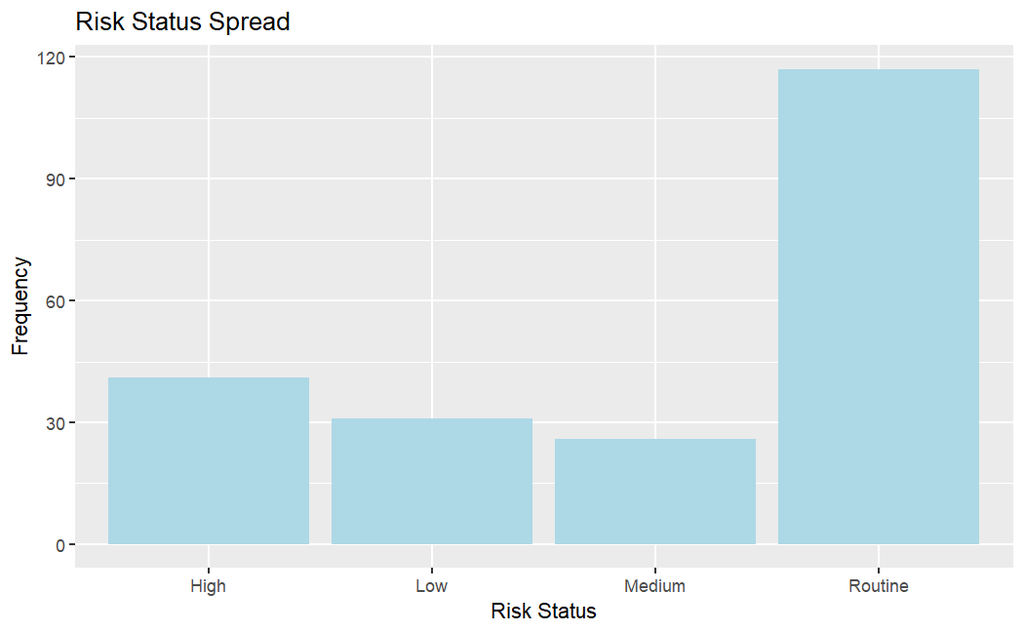

```r
#MERGE Incident and Riskstatus datasets
df <- merge(riskstatus,filtered_incident,by="anon_id")

#density plot of risk categories
ggplot(riskstatus, aes(x=Status))+
  geom_bar(fill="lightblue")+
  labs(title="Risk Status Spread",x="Risk Status",y="Frequency")
```

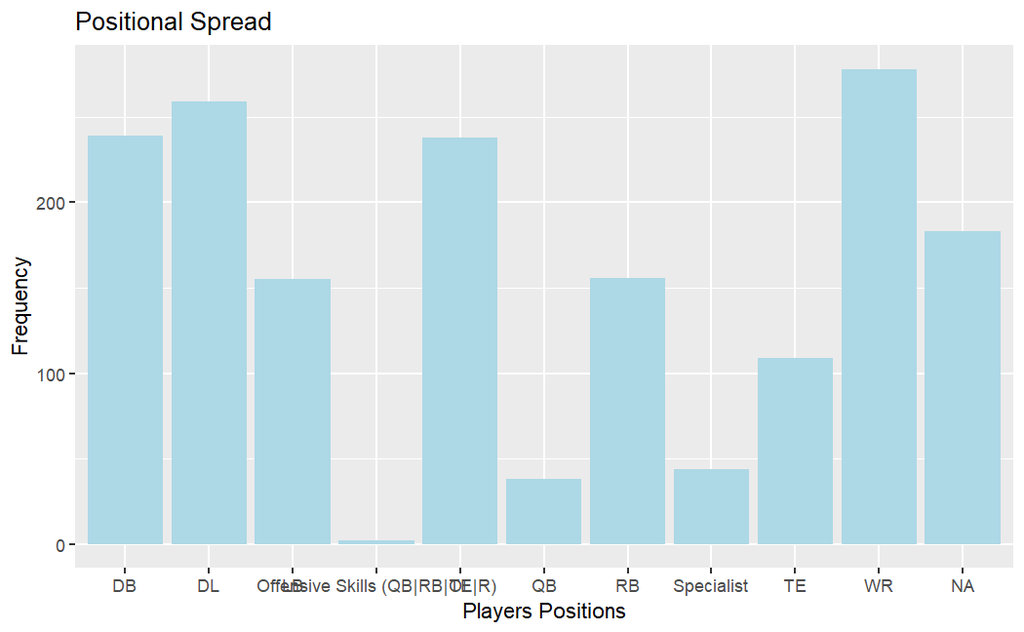

```r
ggplot(filtered_incident, aes(x=Position))+
  geom_bar(fill="lightblue")+
  labs(title="Positional Spread",x="Players Positions",y="Frequency")
```

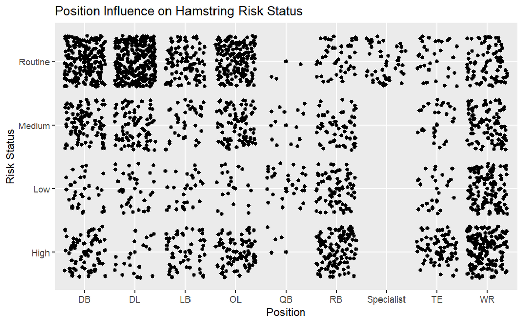

```r
#position by status
ggplot(df,aes(x=Position,y=Status))+  #scatterplot
  geom_point()+
  geom_jitter()+
  labs(title="Position Influence on Hamstring Risk Status",y="Risk Status")
```

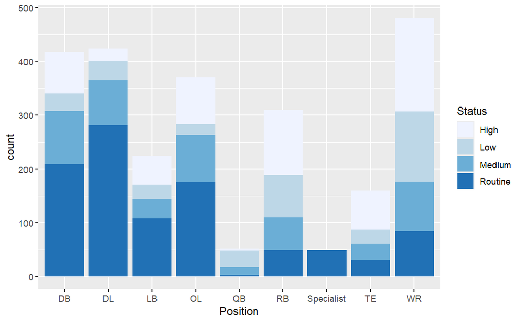

```r
ggplot(df,aes(x=Position,fill=Status))+   #stacked bar chart
  geom_bar(inherit.aes = TRUE)+
  scale_fill_brewer()
```

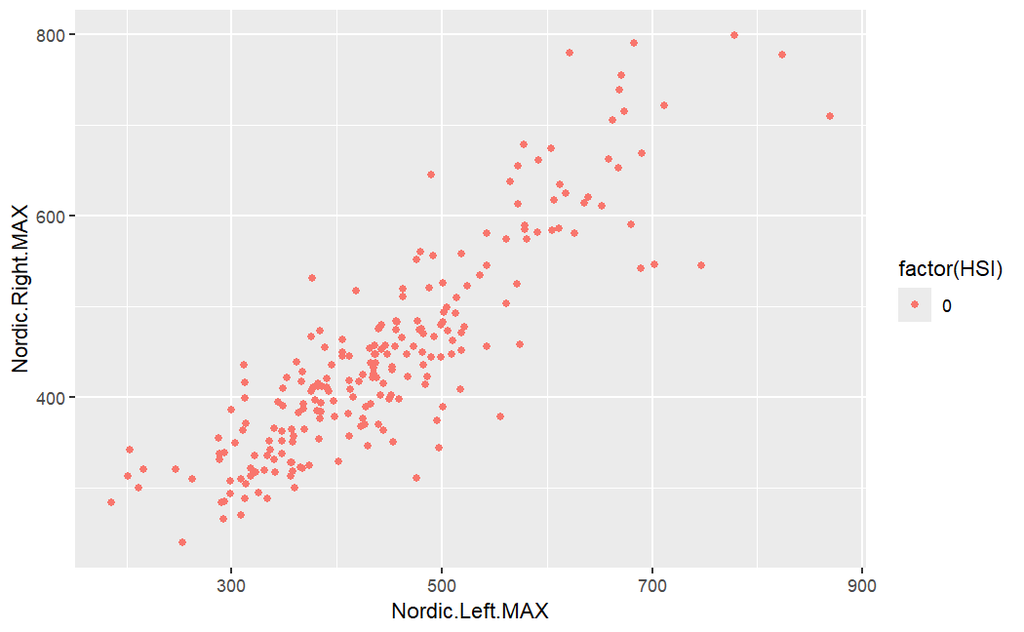

```r
#PLOTS NOT VERY HELPFUL
#Nordic.Left.MAX , Nordic.Right.MAX , color== HSI
ggplot(data=final_merge_full, aes(x=Nordic.Left.MAX, y=Nordic.Right.MAX,color=factor(HSI)))+
  geom_point()
```

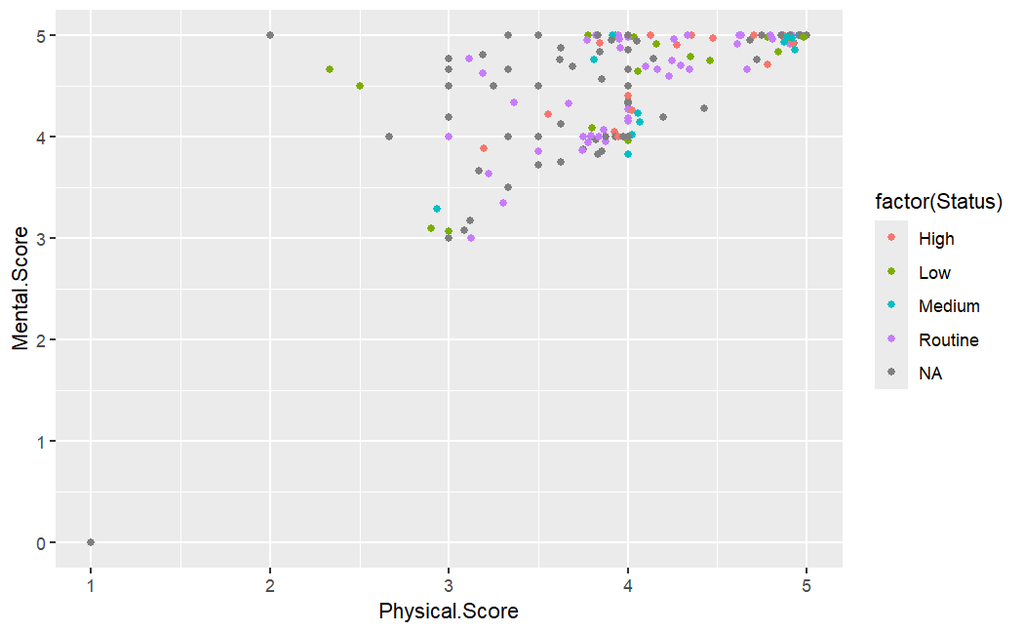

```r
ggplot(data=final_merge_full,aes(x=Physical.Score, y=Mental.Score, color=factor(Status)))+
  geom_point()
```

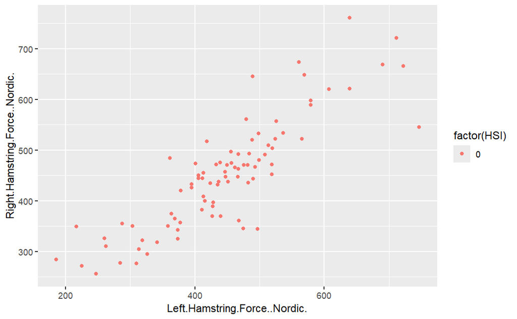

```r
#Left.Hamstring.Force..Nordic.
ggplot(data=final_merge_full, aes(x=Left.Hamstring.Force..Nordic., y=Right.Hamstring.Force..Nordic.,color=factor(HSI)))+
  geom_point()
```

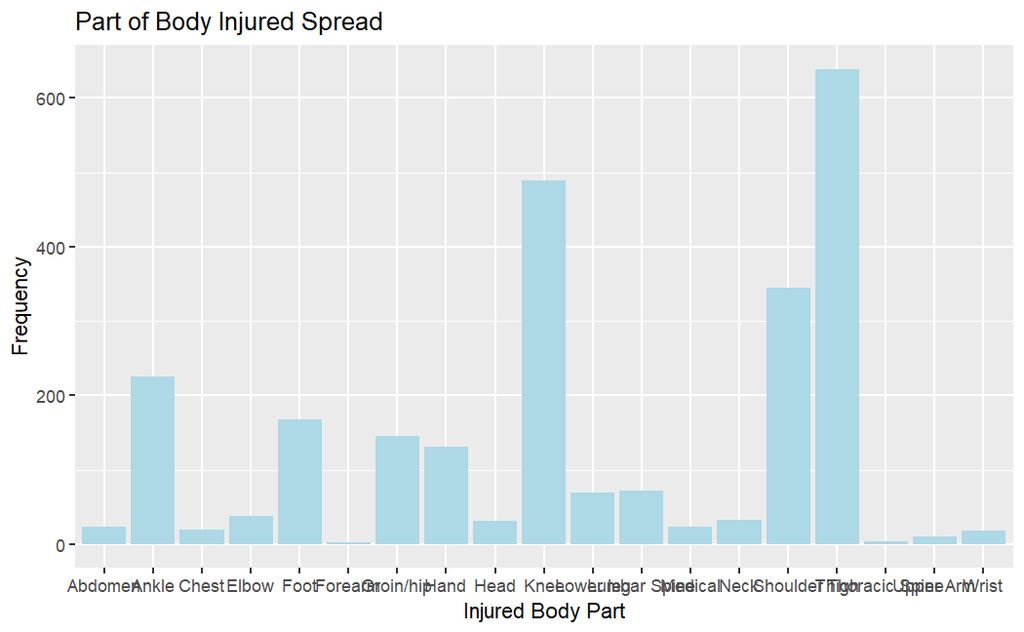

```r
#density plot of Body. part density
ggplot(df, aes(x=Body.Part))+
  geom_bar(fill="lightblue")+
  labs(title="Part of Body Injured Spread",x="Injured Body Part",y="Frequency")
```

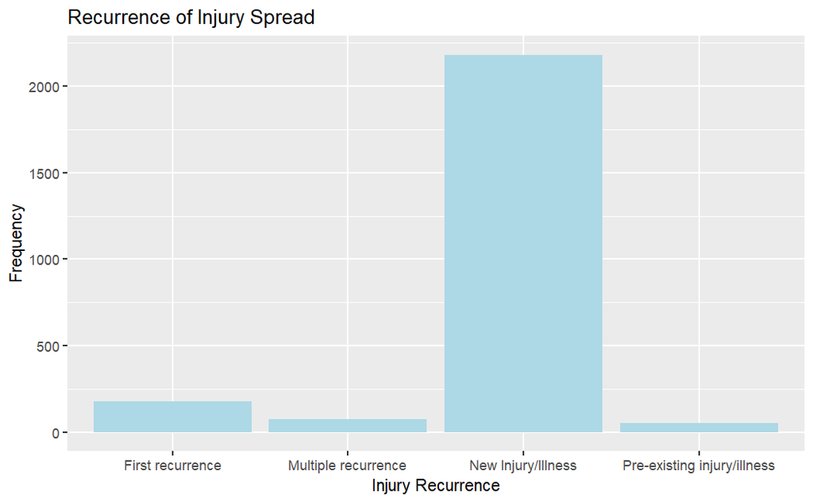

```r
ggplot(df, aes(x=Recurrence.of.Injury))+
  geom_bar(fill="lightblue")+
  labs(title="Recurrence of Injury Spread",x="Injury Recurrence",y="Frequency")
```

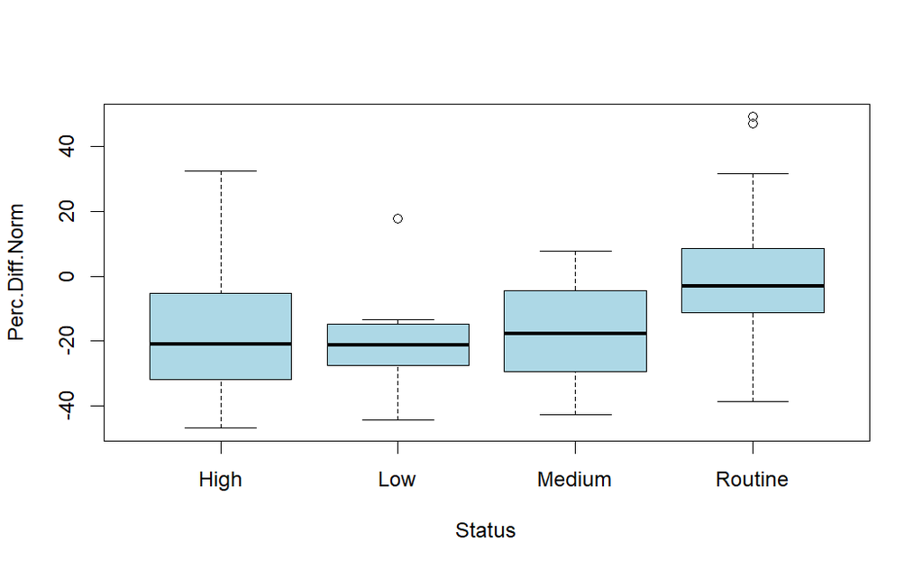

```r
#distributions of strength/imbalance by risk category
boxplot(Perc.Diff.Norm~Status,data=final_merge_full,lmain="Risk Status vs % Difference Norm", col="lightblue")
```

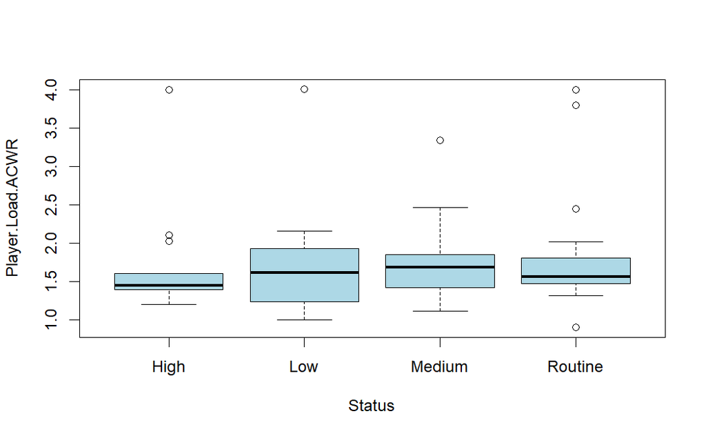

```r
boxplot(Player.Load.ACWR~Status,data=final_merge_full,lmain="Risk Status vs % Difference Norm", col="lightblue")
```

-Lower body injuries are most prevalent .With the thigh which includes the hamstring having the greatest quantity of injuries of the lower body. -Recurrence of injuries is not as high as anticipated. New injuries is the biggest threat to our team.

# Question 1: Validating Soft Tissue Watchlist

## 1. Players Deemed High Risk

```r
#filtering just the high risk athletes from the watchlist
Riskstatus_high <- Riskstatus %>%
  filter(Status == 'High') %>%
  mutate(Date = as.Date(Date, format = '%m/%d/%Y')) %>%
  arrange(Date) %>%
  group_by(anon_id) %>%
  summarize(DateRisk = paste0(Date, collapse = " and "))

#creating a list of the unique athlete ids that were deemed high risk
high_risk <- unique(Riskstatus_high$anon_id)
```

```r
#filtering the incident report to only show those deemed high risk with only lower body injuries as well as only HSI related injuries
incident_hr_all <- filtered_incident %>%
  filter(anon_id %in% high_risk, Body.Part %in% lower_body) %>%
  group_by(anon_id, Date.of.Injury...Onset.of.symptoms) %>%
  mutate(Total.Time.Injured = sum(Total.Time.Injured, na.rm = TRUE)) %>%
  ungroup() %>%
  group_by(across(everything())) %>%
  summarise(.groups = 'drop')

incident_hr_HSI <- filtered_incident %>%
  filter(anon_id %in% high_risk, OSICS14.Code %in% hamstring_OSICS14) %>%
  group_by(anon_id, Date.of.Injury...Onset.of.symptoms) %>%
  mutate(Total.Time.Injured = sum(Total.Time.Injured, na.rm = TRUE)) %>%
  ungroup() %>%
  group_by(across(everything())) %>%
  summarise(.groups = 'drop')

#consolidates all injuries for these athletes into one column
incident_hr_all2 <- incident_hr_all %>%
  mutate(Date = as.Date(Date.of.Injury...Onset.of.symptoms, format = '%m/%d/%Y')) %>%
  arrange(Date) %>%
  group_by(anon_id) %>%
  summarize(Outcome = paste0(FinalDiagnosisIncidentDate, collapse = " and "))

incident_hr_HSI2 <- incident_hr_HSI %>%
  mutate(Date = as.Date(Date.of.Injury...Onset.of.symptoms, format = '%m/%d/%Y')) %>%
  arrange(Date) %>%
  group_by(anon_id) %>%
  summarize(Outcome = paste0(FinalDiagnosisIncidentDate, collapse = " and "))
```

Player ID_194 has a duplicate injury with both ‘Left Hamstring strain/tear’ and ‘Left Semimembranosis/tendinosis strain (grade 1 - 2)’ being listed for 06/05/24.

```r
#combines the dates the athletes were deemed high risk with their injuries and separates the injury occurrences and dates
validation_hr_all <- left_join(Riskstatus_high, incident_hr_all2, by = 'anon_id') %>%
  separate(Outcome, c('Injury.1', 'Injury.2', 'Injury.3', 'Injury.4', 'Injury.5', 'Injury.6', 'Injury.7', 'Injury.8'), sep = ' and ') %>%
  separate(DateRisk, c('Test.1', 'Test.2'), sep = ' and ')

#combines the above but specifically for HSI and includes T/F for whether the athlete suffered their injury after their high risk assessment
validation_hr_HSI <- left_join(Riskstatus_high, incident_hr_HSI2, by = 'anon_id') %>%
  separate(Outcome, c('Injury.1', 'Injury.2', 'Injury.3', 'Injury.4'), sep = ' and ') %>%
  separate(DateRisk, c('Test.1', 'Test.2'), sep = ' and ')

validation_hr_HSI <- validation_hr_HSI %>%
  mutate(Injury.1.After = as.Date(str_sub(validation_hr_HSI$Injury.1, start = -10), format = '%m/%d/%Y') - as.Date(Test.1),
         Injury.2.After = as.Date(str_sub(validation_hr_HSI$Injury.2, start = -10), format = '%m/%d/%Y') - as.Date(Test.1),
         Injury.3.After = as.Date(str_sub(validation_hr_HSI$Injury.3, start = -10), format = '%m/%d/%Y') - as.Date(Test.1),
         Injury.4.After = as.Date(str_sub(validation_hr_HSI$Injury.4, start = -10), format = '%m/%d/%Y') - as.Date(Test.1),
         Injury.1.After.2 = as.Date(str_sub(validation_hr_HSI$Injury.1, start = -10), format = '%m/%d/%Y') - as.Date(Test.2),
         Injury.2.After.2 = as.Date(str_sub(validation_hr_HSI$Injury.2, start = -10), format = '%m/%d/%Y') - as.Date(Test.2),
         Injury.3.After.2 = as.Date(str_sub(validation_hr_HSI$Injury.3, start = -10), format = '%m/%d/%Y') - as.Date(Test.2),
         Injury.4.After.2 = as.Date(str_sub(validation_hr_HSI$Injury.4, start = -10), format = '%m/%d/%Y') - as.Date(Test.2))

#adds columns that return 'Yes' if an injury occurred after the athlete was deemed high risk and a 'No' if no injury occurred after
validation_hr_HSI <- validation_hr_HSI %>%
         mutate(Test.1.Success = ifelse(is.na(Test.1), NA, ifelse(rowSums((dplyr::select(., Injury.1.After:Injury.4.After) > 0), na.rm = TRUE) > 0, 'Yes', 'No')),
         Test.2.Success = ifelse(is.na(Test.2), NA, ifelse(rowSums((dplyr::select(., Injury.1.After.2:Injury.4.After.2) > 0), na.rm = TRUE) > 0, 'Yes', 'No')))
```

### Visualizations

```r
#combining tests and injury outcomes and creating a data frame that just contains the dates of the test results and whether an injury occurred for the athlete after these tests
tests_hr <- c(validation_hr_HSI$Test.1, validation_hr_HSI$Test.2)
outcomes_hr <- c(validation_hr_HSI$Test.1.Success, validation_hr_HSI$Test.2.Success)
tests_outcomes_hr <- data.frame(tests_hr, outcomes_hr) %>%
  na.omit

#calculating percent of the time right
mean(tests_outcomes_hr$outcomes == 'Yes')
```

```
[1] 0.2195122
```

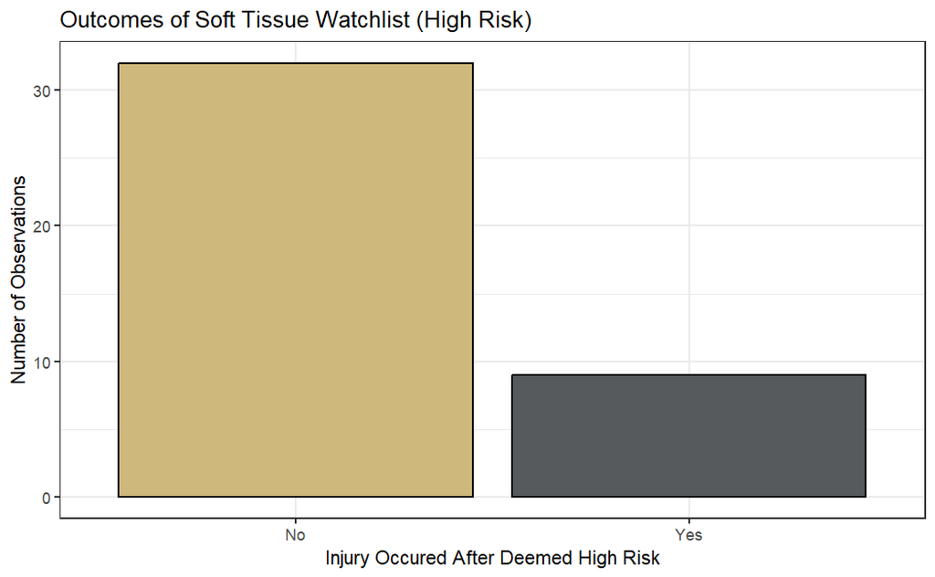

```r
#visualizing using a bar plot
ggplot(tests_outcomes_hr, aes(x = outcomes_hr, fill = outcomes_hr)) +
  geom_bar(color = 'black', show.legend = FALSE) +
  scale_fill_manual(values = c('#CFB87C', '#565A5C')) +
  labs(title = 'Outcomes of Soft Tissue Watchlist (High Risk)',
       x = 'Injury Occured After Deemed High Risk',
       y = 'Number of Observations') +
  theme_bw()
```

In only 21.95122 % of the tests deeming players high risk did a HSI injury occur following. However 19 of these tests were done on 02/27/25 or later and the incident report only goes until April 22, 2025 so there could have been more injuries that occured afterwards unkown to us.

```r
#vectorizes all of the columns containing time from test to injury
all_times <- c(validation_hr_HSI$Injury.1.After, validation_hr_HSI$Injury.2.After, validation_hr_HSI$Injury.3.After, validation_hr_HSI$Injury.4.After, validation_hr_HSI$Injury.1.After.2, validation_hr_HSI$Injury.2.After.2, validation_hr_HSI$Injury.3.After.2, validation_hr_HSI$Injury.4.After.2)

#vectorizes the player ids associated with the times
ids <- c(validation_hr_HSI$anon_id)

#puts the two above vectors into a data frame
length_time <- data.frame(all_times, ids)

#omitting the negative lengths of time and 0 (assuming test was after injury on the same day)
length_time <- length_time %>%
  na.omit() %>%
  mutate(anon_id = ids,
         Test.to.HSI = as.numeric(all_times)) %>%
  arrange(Test.to.HSI) %>%
  dplyr::select(-c(all_times, ids)) %>%
  filter(Test.to.HSI > 0)

length_time1 <- length_time[-c(7, 10),]

#calculating percent of the time right
mean(length_time1$Test.to.HSI)
```

```
[1] 92.66667
```

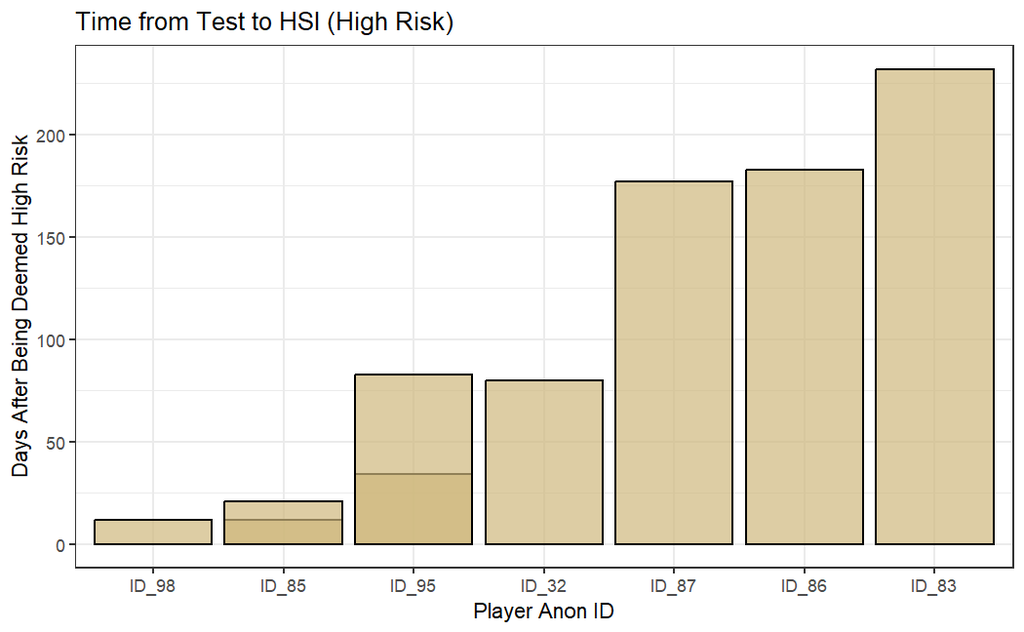

```r
#visualizing using a bar plot
ggplot(length_time1, aes(x = reorder(anon_id, Test.to.HSI), y = Test.to.HSI)) +
  geom_col(fill = '#CFB87C', color = 'black', position = "identity", alpha = 0.7) +
  labs(title = 'Time from Test to HSI (High Risk)',
       x = 'Player Anon ID',
       y = 'Days After Being Deemed High Risk') +
  theme_bw()
```

Consider why flagged and if they suffered another injury, 6 months

Players ID_220 and ID_83 was deemed high risk on the same day they suffered a hamstring injury, I classified them into the not accurate category. Player ID_307 suffered a tendon injury (not strain/tear) after over 3 months from the test. Player_ID 32 suffered his injury in just over 2 months. Player ID_83 suffered his injury in just under 8 months from the first test. Player ID_85 had injuries after both tests, with the first coming within the month of the test and second coming within the month of the second test. Player ID_86 and ID_87 injured their hamstrings in just under 6 months from their first tests. Player ID_95 injured his hamstring once after just over a month and a second time after under 3 months from the same test. Player ID_98 suffered a single injury after both of his tests, it being under 5 months from the first test and within a month from the second.

Statistics: * 9 of the 41 times a player was deemed “High” risk the player experienced HSI afterwards * Player ID_95 experienced HSI twice after being deemed “High” risk, 34 and 83 days after * Player ID_220 and ID_83 were deemed high risk on the same day they suffered HSI * Incident report goes from August 29, 2023 to April 22, 2025 * Soft-Tissue Watchlist goes from June 27, 2024 to April 23, 2025. This means some classifications cannot be verified as not enough time has passed * Average time to HSI from being deemed “High” risk in cases of success is 92.66667 days * Player ID_83 had the longest time of 232 days * Player ID_85 and ID_98 had the shortest, experienceing HSI only 12 days after

### Correlation Tests

```r
#cor(final_merge_full %>% select_if(is.numeric))
cor(filter_full3_merge  %>% select_if(is.numeric))
```

```
                                    Injuries.Last.3.Months Maximum.Force
Injuries.Last.3.Months                          1.00000000   -0.02156110
Maximum.Force                                  -0.02156110    1.00000000
Nordic.Left.MAX                                -0.02156110    1.00000000
Nordic.Right.MAX                                0.01499323    0.87136420
Nordic.MEAN.Imbalance.with.side                 0.01936128   -0.33908454
Nordic...Difference.from.First.Test            -0.11027771    0.09595743
Overall.Wellness.Score                          0.21020863   -0.27478907
HSI                                            -0.02564103   -0.15880095
                                    Nordic.Left.MAX Nordic.Right.MAX
Injuries.Last.3.Months                  -0.02156110       0.01499323
Maximum.Force                            1.00000000       0.87136420
Nordic.Left.MAX                          1.00000000       0.87136420
Nordic.Right.MAX                         0.87136420       1.00000000
Nordic.MEAN.Imbalance.with.side         -0.33908454       0.12904389
Nordic...Difference.from.First.Test      0.09595743       0.16659206
Overall.Wellness.Score                  -0.27478907      -0.28354220
HSI                                     -0.15880095      -0.05877448
                                    Nordic.MEAN.Imbalance.with.side
Injuries.Last.3.Months                                   0.01936128
Maximum.Force                                           -0.33908454
Nordic.Left.MAX                                         -0.33908454
Nordic.Right.MAX                                         0.12904389
Nordic.MEAN.Imbalance.with.side                          1.00000000
Nordic...Difference.from.First.Test                      0.06082739
Overall.Wellness.Score                                   0.12662152
HSI                                                      0.17785677
                                    Nordic...Difference.from.First.Test
Injuries.Last.3.Months                                     -0.110277713
Maximum.Force                                               0.095957426
Nordic.Left.MAX                                             0.095957426
Nordic.Right.MAX                                            0.166592057
Nordic.MEAN.Imbalance.with.side                             0.060827388
Nordic...Difference.from.First.Test                         1.000000000
Overall.Wellness.Score                                     -0.003338307
HSI                                                         0.110455236
                                    Overall.Wellness.Score         HSI
Injuries.Last.3.Months                         0.210208629 -0.02564103
Maximum.Force                                 -0.274789072 -0.15880095
Nordic.Left.MAX                               -0.274789072 -0.15880095
Nordic.Right.MAX                              -0.283542198 -0.05877448
Nordic.MEAN.Imbalance.with.side                0.126621515  0.17785677
Nordic...Difference.from.First.Test           -0.003338307  0.11045524
Overall.Wellness.Score                         1.000000000  0.05797042
HSI                                            0.057970419  1.00000000
```

```r
#necessary libraries
library(caret)
library(pROC)
library(lme4)
library(survival)
library(rpart)
library(glmnet)
```

### 3 MONTH VALIDATION

```r
sum(final_merge_full$HSI)      # total OBS 1782, HSI= 16/1782= 0.89%
```

```
[1] 0
```

```r
sum(HSIincident_vs_risk2$HSI)  # total OBS 2487, HSI=56/2487= 2.25 %
```

```
[1] 56
```

```r
#Stepwise validation through 2 best combined datasets
table(final_merge_full$Status,final_merge_full$HSI)
```

```
           0
  High    22
  Low     20
  Medium  20
  Routine 75
```

```r
table(HSIincident_vs_risk2$Status,HSIincident_vs_risk2$HSI)
```

```
            0   1
  High    577  34
  Low     370  11
  Medium  504   0
  Routine 980  11
```

```r
#ordinal variable
HSIincident_vs_risk2$Status <- factor(
  HSIincident_vs_risk2$Status,
  levels = c("Routine", "Low", "Medium", "High"),
  ordered = TRUE
)
#logistic regression
model_q1 <- glm(HSI~Status, data=HSIincident_vs_risk2, family="binomial")
summary(model_q1)
```

```
Call:
glm(formula = HSI ~ Status, family = "binomial", data = HSIincident_vs_risk2)

Coefficients:
            Estimate Std. Error z value Pr(>|z|)
(Intercept)   -7.851    197.443  -0.040    0.968
Status.L      -2.700    176.599  -0.015    0.988
Status.Q       8.380    394.887   0.021    0.983
Status.C      11.809    529.796   0.022    0.982

(Dispersion parameter for binomial family taken to be 1)

    Null deviance: 535.60  on 2486  degrees of freedom
Residual deviance: 483.07  on 2483  degrees of freedom
AIC: 491.07

Number of Fisher Scoring iterations: 19
```

```r
exp(coef(model_q1))   #ODDS RATIO
```

```
 (Intercept)     Status.L     Status.Q     Status.C
3.894777e-04 6.718798e-02 4.360180e+03 1.344001e+05
```

```r
#model evaluation
HSIincident_vs_risk2$pred_prob_q1 <- predict(model_q1,type="response")
HSIincident_vs_risk2$pred_class_q1 <- ifelse(HSIincident_vs_risk2$pred_prob_q1>0.5,1,0) #class w/ 0.5 threshold

#convert both predicted + actual to factors w/ the same levels
pred <- factor(HSIincident_vs_risk2$pred_class_q1, levels = c(0, 1))
actual <- factor(HSIincident_vs_risk2$HSI, levels = c(0, 1))

#confusion matrix
confusionMatrix(pred, actual)
```

```
Confusion Matrix and Statistics

          Reference
Prediction    0    1
         0 2431   56
         1    0    0

               Accuracy : 0.9775
                 95% CI : (0.9709, 0.9829)
    No Information Rate : 0.9775
    P-Value [Acc > NIR] : 0.5355

                  Kappa : 0

 Mcnemar's Test P-Value : 1.987e-13

            Sensitivity : 1.0000
            Specificity : 0.0000
         Pos Pred Value : 0.9775
         Neg Pred Value :    NaN
             Prevalence : 0.9775
         Detection Rate : 0.9775
   Detection Prevalence : 1.0000
      Balanced Accuracy : 0.5000

       'Positive' Class : 0
```

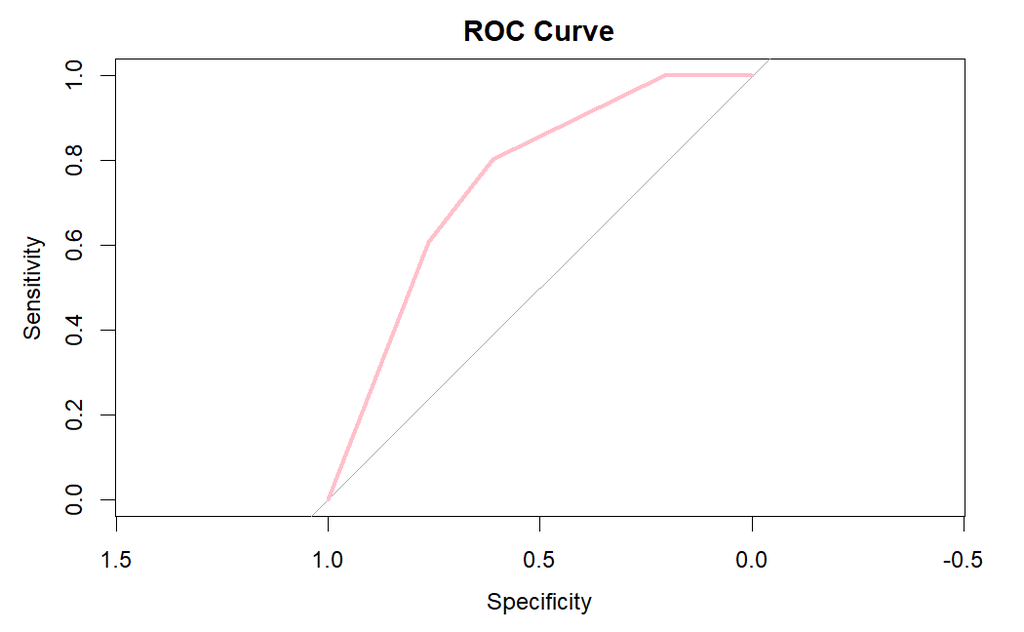

```r
#ROC CURVE
roc_obj <- roc(HSIincident_vs_risk2$HSI, HSIincident_vs_risk2$pred_prob_q1)
plot(roc_obj, main="ROC Curve", col="pink",lwd=3)
```

```r
auc(roc_obj)
```

```
Area under the curve: 0.7503
```

```r
#calculate proportions
table_high <- table(HSIincident_vs_risk2$HSI[HSIincident_vs_risk2$Status=="High"])
incidence_high <- prop.table(table_high)[2]   #P(HSI|High)

table_others <- table(HSIincident_vs_risk2$HSI[HSIincident_vs_risk2$Status!="High"])
incidence_others <- prop.table(table_others)[2]   #P(HSI|Not High)

table_flag <-table(HSIincident_vs_risk2$Status=="High",HSIincident_vs_risk2$HSI)
chisq.test(table_flag)
```

```
    Pearson's Chi-squared test with Yates' continuity correction

data:  table_flag
X-squared = 38.421, df = 1, p-value = 5.702e-10
```

```r
fisher.test(table_flag)    # aplha=0.05
```

```
    Fisher's Exact Test for Count Data

data:  table_flag
p-value = 6.506e-09
alternative hypothesis: true odds ratio is not equal to 1
95 percent confidence interval:
 2.793555 8.984417
sample estimates:
odds ratio
  4.962106
```

P-values < alpha therefore statistically significant.

## 2. Players Deemed Low Risk

```r
#filtering just the low risk athletes from the watchlist
Riskstatus_low <- Riskstatus %>%
  filter(Status == 'Low') %>%
  mutate(Date = as.Date(Date, format = '%m/%d/%Y')) %>%
  arrange(Date) %>%
  group_by(anon_id) %>%
  summarize(DateRisk = paste0(Date, collapse = " and "))

#creating a list of the unique athlete ids that were deemed high risk
low_risk <- unique(Riskstatus_low$anon_id)
```

```r
#filtering the incident report to only show those deemed low risk with only lower body injuries as well as only HSI related injuries
incident_lr_all <- filtered_incident %>%
  filter(anon_id %in% low_risk, Body.Part %in% lower_body) %>%
  group_by(anon_id, Date.of.Injury...Onset.of.symptoms) %>%
  mutate(Total.Time.Injured = sum(Total.Time.Injured, na.rm = TRUE)) %>%
  ungroup() %>%
  group_by(across(everything())) %>%
  summarise(.groups = 'drop')

incident_lr_HSI <- filtered_incident %>%
  filter(anon_id %in% low_risk, OSICS14.Code %in% hamstring_OSICS14) %>%
  group_by(anon_id, Date.of.Injury...Onset.of.symptoms) %>%
  mutate(Total.Time.Injured = sum(Total.Time.Injured, na.rm = TRUE)) %>%
  ungroup() %>%
  group_by(across(everything())) %>%
  summarise(.groups = 'drop')

#consolidates all injuries for these athletes into one column
incident_lr_all2 <- incident_lr_all %>%
  mutate(Date = as.Date(Date.of.Injury...Onset.of.symptoms, format = '%m/%d/%Y')) %>%
  arrange(Date) %>%
  group_by(anon_id) %>%
  summarize(Outcome = paste0(FinalDiagnosisIncidentDate, collapse = " and "))

incident_lr_HSI2 <- incident_lr_HSI %>%
  mutate(Date = as.Date(Date.of.Injury...Onset.of.symptoms, format = '%m/%d/%Y')) %>%
  arrange(Date) %>%
  group_by(anon_id) %>%
  summarize(Outcome = paste0(FinalDiagnosisIncidentDate, collapse = " and "))
```

Player ID_194 has a duplicate injury with both ‘Left Hamstring strain/tear’ and ‘Left Semimembranosis/tendinosis strain (grade 1 - 2)’ being listed for 06/05/24. Player ID_360 has a duplicate injury with both ‘Left Ankle sprains’ and ‘Left Peroneal tendinopathy’ being listed for 11/21/24, but this is less important as it only relates to ankles.

```r
#combines the dates the athletes were deemed high risk with their injuries and separates the injury occurrences and dates
validation_lr_all <- left_join(Riskstatus_low, incident_lr_all2, by = 'anon_id') %>%
  separate(Outcome, c('Injury.1', 'Injury.2', 'Injury.3', 'Injury.4', 'Injury.5', 'Injury.6', 'Injury.7', 'Injury.8'), sep = ' and ') %>%
  separate(DateRisk, c('Test.1', 'Test.2'), sep = ' and ')

#combines the above but specifically for HSI and includes T/F for whether the athlete suffered their injury after their high risk assessment
validation_lr_HSI <- left_join(Riskstatus_low, incident_lr_HSI2, by = 'anon_id') %>%
  separate(Outcome, c('Injury.1', 'Injury.2', 'Injury.3', 'Injury.4'), sep = ' and ') %>%
  separate(DateRisk, c('Test.1', 'Test.2'), sep = ' and ')

validation_lr_HSI <- validation_lr_HSI %>%
  mutate(Injury.1.After = as.Date(str_sub(validation_lr_HSI$Injury.1, start = -10), format = '%m/%d/%Y') - as.Date(Test.1),
         Injury.2.After = as.Date(str_sub(validation_lr_HSI$Injury.2, start = -10), format = '%m/%d/%Y') - as.Date(Test.1),
         Injury.3.After = as.Date(str_sub(validation_lr_HSI$Injury.3, start = -10), format = '%m/%d/%Y') - as.Date(Test.1),
         Injury.4.After = as.Date(str_sub(validation_lr_HSI$Injury.4, start = -10), format = '%m/%d/%Y') - as.Date(Test.1),
         Injury.1.After.2 = as.Date(str_sub(validation_lr_HSI$Injury.1, start = -10), format = '%m/%d/%Y') - as.Date(Test.2),
         Injury.2.After.2 = as.Date(str_sub(validation_lr_HSI$Injury.2, start = -10), format = '%m/%d/%Y') - as.Date(Test.2),
         Injury.3.After.2 = as.Date(str_sub(validation_lr_HSI$Injury.3, start = -10), format = '%m/%d/%Y') - as.Date(Test.2),
         Injury.4.After.2 = as.Date(str_sub(validation_lr_HSI$Injury.4, start = -10), format = '%m/%d/%Y') - as.Date(Test.2))

#adds columns that return 'Yes' if an injury occurred after the athlete was deemed high risk and a 'No' if no injury occurred after
validation_lr_HSI <- validation_lr_HSI %>%
         mutate(Test.1.Success = ifelse(is.na(Test.1), NA, ifelse(rowSums((dplyr::select(., Injury.1.After:Injury.4.After) > 0), na.rm = TRUE) > 0, 'Yes', 'No')),
         Test.2.Success = ifelse(is.na(Test.2), NA, ifelse(rowSums((dplyr::select(., Injury.1.After.2:Injury.4.After.2) > 0), na.rm = TRUE) > 0, 'Yes', 'No')))
```

### Visualizations

```r
#combining tests and injury outcomes and creating a data frame that just contains the dates of the test results and whether an injury occurred for the athlete after these tests
tests_lr <- c(validation_lr_HSI$Test.1, validation_lr_HSI$Test.2)
outcomes_lr <- c(validation_lr_HSI$Test.1.Success, validation_lr_HSI$Test.2.Success)
tests_outcomes_lr <- data.frame(tests_lr, outcomes_lr) %>%
  na.omit

#calculating percent of the time right
mean(tests_outcomes_lr$outcomes == 'Yes')
```

```
[1] 0.06451613
```

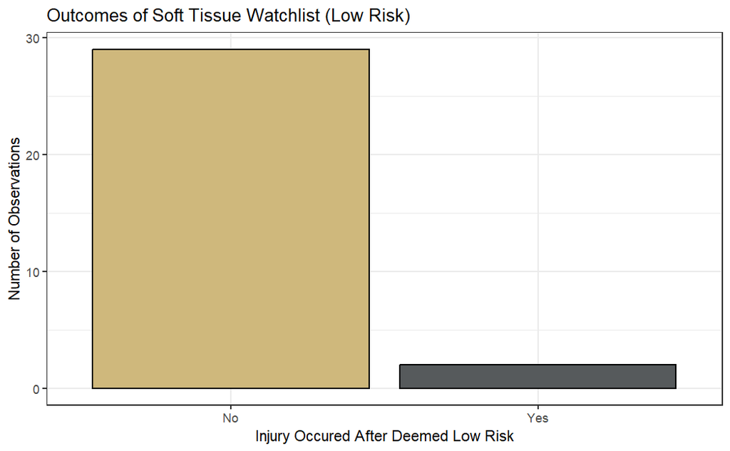

```r
#visualizing using a bar plot
ggplot(tests_outcomes_lr, aes(x = outcomes_lr, fill = outcomes_lr)) +
  geom_bar(color = 'black', show.legend = FALSE) +
  scale_fill_manual(values = c('#CFB87C', '#565A5C')) +
  labs(title = 'Outcomes of Soft Tissue Watchlist (Low Risk)',
       x = 'Injury Occured After Deemed Low Risk',
       y = 'Number of Observations') +
  theme_bw()
```

Important to note that only two hamstring injuries occured in players deemed low risk with one occuring almost 6 months after being deemed low risk. Player ID_111 hurt his hamstring 135, 171, 219, and 238 days after being deemed low risk.

## 3. Players Deemed Medium Risk

```r
#filtering just the low risk athletes from the watchlist
Riskstatus_med <- Riskstatus %>%
  filter(Status == 'Medium') %>%
  mutate(Date = as.Date(Date, format = '%m/%d/%Y')) %>%
  arrange(Date) %>%
  group_by(anon_id) %>%
  summarize(DateRisk = paste0(Date, collapse = " and "))

#creating a list of the unique athlete ids that were deemed high risk
med_risk <- unique(Riskstatus_med$anon_id)
```

```r
#filtering the incident report to only show those deemed low risk with only lower body injuries as well as only HSI related injuries
incident_med_all <- filtered_incident %>%
  filter(anon_id %in% med_risk, Body.Part %in% lower_body) %>%
  group_by(anon_id, Date.of.Injury...Onset.of.symptoms) %>%
  mutate(Total.Time.Injured = sum(Total.Time.Injured, na.rm = TRUE)) %>%
  ungroup() %>%
  group_by(across(everything())) %>%
  summarise(.groups = 'drop')

incident_med_HSI <- filtered_incident %>%
  filter(anon_id %in% med_risk, OSICS14.Code %in% hamstring_OSICS14) %>%
  group_by(anon_id, Date.of.Injury...Onset.of.symptoms) %>%
  mutate(Total.Time.Injured = sum(Total.Time.Injured, na.rm = TRUE)) %>%
  ungroup() %>%
  group_by(across(everything())) %>%
  summarise(.groups = 'drop')

#consolidates all injuries for these athletes into one column
incident_med_all2 <- incident_med_all %>%
  mutate(Date = as.Date(Date.of.Injury...Onset.of.symptoms, format = '%m/%d/%Y')) %>%
  arrange(Date) %>%
  group_by(anon_id) %>%
  summarize(Outcome = paste0(FinalDiagnosisIncidentDate, collapse = " and "))

incident_med_HSI2 <- incident_med_HSI %>%
  mutate(Date = as.Date(Date.of.Injury...Onset.of.symptoms, format = '%m/%d/%Y')) %>%
  arrange(Date) %>%
  group_by(anon_id) %>%
  summarize(Outcome = paste0(FinalDiagnosisIncidentDate, collapse = " and "))
```

Player ID_489 has a duplicate injury with both ‘Left Knee medial collateral ligament injury’ and ‘Left Grade 2 MCL tear knee’ being listed for 11/23/24, but this is not as important to us. Player ID_595 has a duplicate injury of ‘Left Ankle sprains’ on 08/15/24.

```r
#combines the dates the athletes were deemed high risk with their injuries and separates the injury occurrences and dates
validation_med_all <- left_join(Riskstatus_med, incident_med_all2, by = 'anon_id') %>%
  separate(Outcome, c('Injury.1', 'Injury.2', 'Injury.3', 'Injury.4', 'Injury.5', 'Injury.6', 'Injury.7', 'Injury.8'), sep = ' and ') %>%
  separate(DateRisk, c('Test.1', 'Test.2'), sep = ' and ')

#combines the above but specifically for HSI and includes T/F for whether the athlete suffered their injury after their high risk assessment
validation_med_HSI <- left_join(Riskstatus_med, incident_med_HSI2, by = 'anon_id') %>%
  separate(Outcome, c('Injury.1', 'Injury.2', 'Injury.3', 'Injury.4'), sep = ' and ') %>%
  separate(DateRisk, c('Test.1', 'Test.2'), sep = ' and ')

validation_med_HSI <- validation_med_HSI %>%
  mutate(Injury.1.After = as.Date(str_sub(validation_med_HSI$Injury.1, start = -10), format = '%m/%d/%Y') - as.Date(Test.1),
         Injury.2.After = as.Date(str_sub(validation_med_HSI$Injury.2, start = -10), format = '%m/%d/%Y') - as.Date(Test.1),
         Injury.3.After = as.Date(str_sub(validation_med_HSI$Injury.3, start = -10), format = '%m/%d/%Y') - as.Date(Test.1),
         Injury.4.After = as.Date(str_sub(validation_med_HSI$Injury.4, start = -10), format = '%m/%d/%Y') - as.Date(Test.1),
         Injury.1.After.2 = as.Date(str_sub(validation_med_HSI$Injury.1, start = -10), format = '%m/%d/%Y') - as.Date(Test.2),
         Injury.2.After.2 = as.Date(str_sub(validation_med_HSI$Injury.2, start = -10), format = '%m/%d/%Y') - as.Date(Test.2),
         Injury.3.After.2 = as.Date(str_sub(validation_med_HSI$Injury.3, start = -10), format = '%m/%d/%Y') - as.Date(Test.2),
         Injury.4.After.2 = as.Date(str_sub(validation_med_HSI$Injury.4, start = -10), format = '%m/%d/%Y') - as.Date(Test.2))

#adds columns that return 'Yes' if an injury occurred after the athlete was deemed high risk and a 'No' if no injury occurred after
validation_med_HSI <- validation_med_HSI %>%
         mutate(Test.1.Success = ifelse(is.na(Test.1), NA, ifelse(rowSums((dplyr::select(., Injury.1.After:Injury.4.After) > 0), na.rm = TRUE) > 0, 'Yes', 'No')),
         Test.2.Success = ifelse(is.na(Test.2), NA, ifelse(rowSums((dplyr::select(., Injury.1.After.2:Injury.4.After.2) > 0), na.rm = TRUE) > 0, 'Yes', 'No')))
```

### Visualizations

```r
#combining tests and injury outcomes and creating a data frame that just contains the dates of the test results and whether an injury occurred for the athlete after these tests
tests_med <- c(validation_med_HSI$Test.1, validation_med_HSI$Test.2)
outcomes_med <- c(validation_med_HSI$Test.1.Success, validation_med_HSI$Test.2.Success)
tests_outcomes_med <- data.frame(tests_med, outcomes_med) %>%
  na.omit

#calculating percent of the time right
mean(tests_outcomes_med$outcomes == 'Yes')
```

```
[1] 0
```

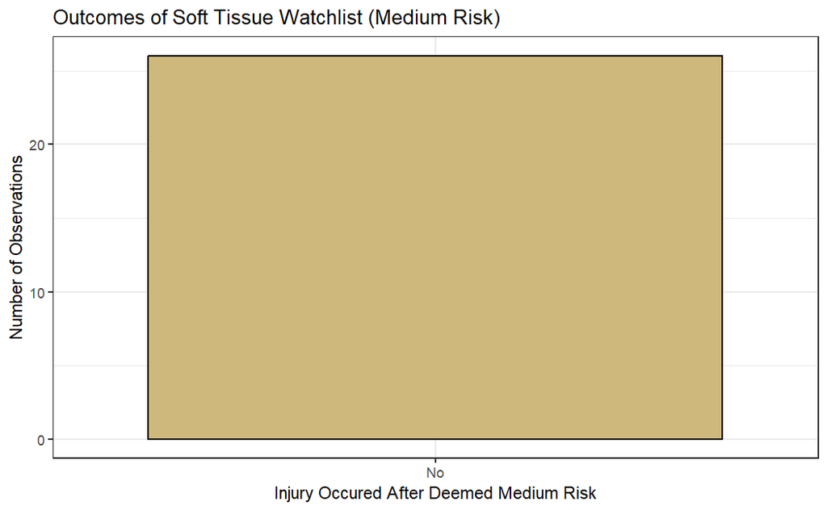

```r
#visualizing using a bar plot
ggplot(tests_outcomes_med, aes(x = outcomes_med, fill = outcomes_med)) +
  geom_bar(color = 'black', show.legend = FALSE) +
  scale_fill_manual(values = c('#CFB87C', '#565A5C')) +
  labs(title = 'Outcomes of Soft Tissue Watchlist (Medium Risk)',
       x = 'Injury Occured After Deemed Medium Risk',
       y = 'Number of Observations') +
  theme_bw()
```

There appear to be no observations of HSI following a player being deemed as “Medium” risk for injury.

## 4. Players Deemed Routine Risk

```r
#filtering just the low risk athletes from the watchlist
Riskstatus_rout <- Riskstatus %>%
  filter(Status == 'Routine') %>%
  mutate(Date = as.Date(Date, format = '%m/%d/%Y')) %>%
  arrange(Date) %>%
  group_by(anon_id) %>%
  summarize(DateRisk = paste0(Date, collapse = " and "))

#creating a list of the unique athlete ids that were deemed high risk
rout_risk <- unique(Riskstatus_rout$anon_id)
```

```r
#filtering the incident report to only show those deemed low risk with only lower body injuries as well as only HSI related injuries
incident_rout_all <- filtered_incident %>%
  filter(anon_id %in% rout_risk, Body.Part %in% lower_body) %>%
  group_by(anon_id, Date.of.Injury...Onset.of.symptoms) %>%
  mutate(Total.Time.Injured = sum(Total.Time.Injured, na.rm = TRUE)) %>%
  ungroup() %>%
  group_by(across(everything())) %>%
  summarise(.groups = 'drop')

incident_rout_HSI <- filtered_incident %>%
  filter(anon_id %in% rout_risk, OSICS14.Code %in% hamstring_OSICS14) %>%
  group_by(anon_id, Date.of.Injury...Onset.of.symptoms) %>%
  mutate(Total.Time.Injured = sum(Total.Time.Injured, na.rm = TRUE)) %>%
  ungroup() %>%
  group_by(across(everything())) %>%
  summarise(.groups = 'drop')

#consolidates all injuries for these athletes into one column
incident_rout_all2 <- incident_rout_all %>%
  mutate(Date = as.Date(Date.of.Injury...Onset.of.symptoms, format = '%m/%d/%Y')) %>%
  arrange(Date) %>%
  group_by(anon_id) %>%
  summarize(Outcome = paste0(FinalDiagnosisIncidentDate, collapse = " and "))

incident_rout_HSI2 <- incident_rout_HSI %>%
  mutate(Date = as.Date(Date.of.Injury...Onset.of.symptoms, format = '%m/%d/%Y')) %>%
  arrange(Date) %>%
  group_by(anon_id) %>%
  summarize(Outcome = paste0(FinalDiagnosisIncidentDate, collapse = " and "))
```

Player ID_489 has a duplicate injury with both ‘Left Knee medial collateral ligament injury’ and ‘Left Grade 2 MCL tear knee’ being listed for 11/23/24, but this is not as important to us. Player ID_595 has a duplicate injury of ‘Left Ankle sprains’ on 08/15/24.

```r
#combines the dates the athletes were deemed high risk with their injuries and separates the injury occurrences and dates
validation_rout_all <- left_join(Riskstatus_rout, incident_rout_all2, by = 'anon_id') %>%
  separate(Outcome, c('Injury.1', 'Injury.2', 'Injury.3', 'Injury.4', 'Injury.5', 'Injury.6', 'Injury.7', 'Injury.8'), sep = ' and ') %>%
  separate(DateRisk, c('Test.1', 'Test.2'), sep = ' and ')

#combines the above but specifically for HSI and includes T/F for whether the athlete suffered their injury after their high risk assessment
validation_rout_HSI <- left_join(Riskstatus_rout, incident_rout_HSI2, by = 'anon_id') %>%
  separate(Outcome, c('Injury.1', 'Injury.2', 'Injury.3', 'Injury.4'), sep = ' and ') %>%
  separate(DateRisk, c('Test.1', 'Test.2'), sep = ' and ')

validation_rout_HSI <- validation_rout_HSI %>%
  mutate(Injury.1.After = as.Date(str_sub(validation_rout_HSI$Injury.1, start = -10), format = '%m/%d/%Y') - as.Date(Test.1),
         Injury.2.After = as.Date(str_sub(validation_rout_HSI$Injury.2, start = -10), format = '%m/%d/%Y') - as.Date(Test.1),
         Injury.3.After = as.Date(str_sub(validation_rout_HSI$Injury.3, start = -10), format = '%m/%d/%Y') - as.Date(Test.1),
         Injury.4.After = as.Date(str_sub(validation_rout_HSI$Injury.4, start = -10), format = '%m/%d/%Y') - as.Date(Test.1),
         Injury.1.After.2 = as.Date(str_sub(validation_rout_HSI$Injury.1, start = -10), format = '%m/%d/%Y') - as.Date(Test.2),
         Injury.2.After.2 = as.Date(str_sub(validation_rout_HSI$Injury.2, start = -10), format = '%m/%d/%Y') - as.Date(Test.2),
         Injury.3.After.2 = as.Date(str_sub(validation_rout_HSI$Injury.3, start = -10), format = '%m/%d/%Y') - as.Date(Test.2),
         Injury.4.After.2 = as.Date(str_sub(validation_rout_HSI$Injury.4, start = -10), format = '%m/%d/%Y') - as.Date(Test.2))

#adds columns that return 'Yes' if an injury occurred after the athlete was deemed high risk and a 'No' if no injury occurred after
validation_rout_HSI <- validation_rout_HSI %>%
         mutate(Test.1.Success = ifelse(is.na(Test.1), NA, ifelse(rowSums((dplyr::select(., Injury.1.After:Injury.4.After) > 0), na.rm = TRUE) > 0, 'Yes', 'No')),
         Test.2.Success = ifelse(is.na(Test.2), NA, ifelse(rowSums((dplyr::select(., Injury.1.After.2:Injury.4.After.2) > 0), na.rm = TRUE) > 0, 'Yes', 'No')))
```

### Visualizations

```r
#combining tests and injury outcomes and creating a data frame that just contains the dates of the test results and whether an injury occurred for the athlete after these tests
tests_rout <- c(validation_rout_HSI$Test.1, validation_rout_HSI$Test.2)
outcomes_rout <- c(validation_rout_HSI$Test.1.Success, validation_rout_HSI$Test.2.Success)
tests_outcomes_rout <- data.frame(tests_rout, outcomes_rout) %>%
  na.omit

#calculating percent of the time right
mean(tests_outcomes_rout$outcomes == 'Yes')
```

```
[1] 0.05128205
```

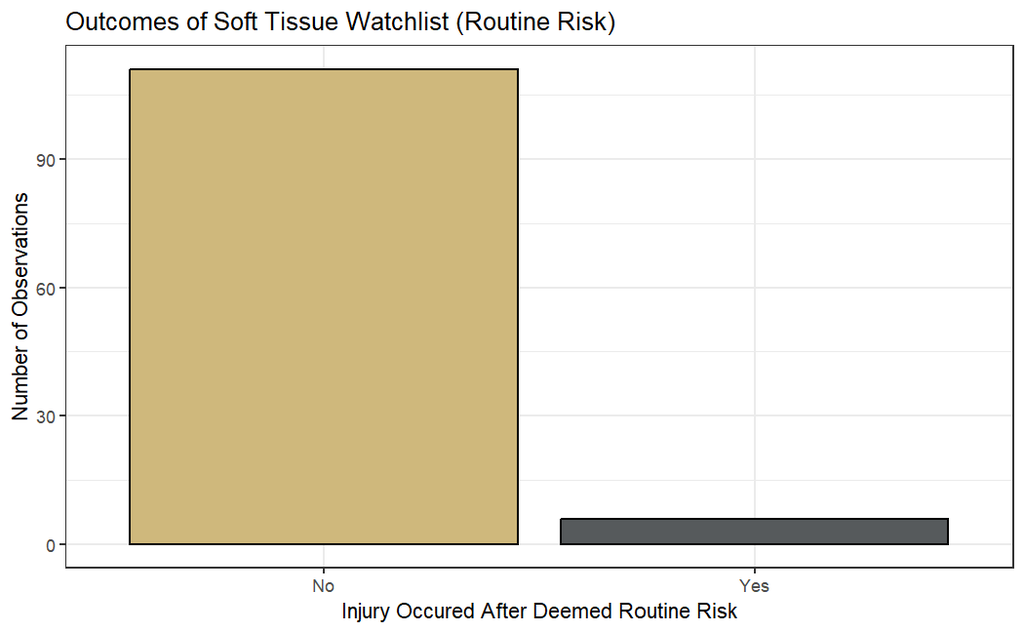

```r
#visualizing using a bar plot
ggplot(tests_outcomes_rout, aes(x = outcomes_rout, fill = outcomes_rout)) +
  geom_bar(color = 'black', show.legend = FALSE) +
  scale_fill_manual(values = c('#CFB87C', '#565A5C')) +
  labs(title = 'Outcomes of Soft Tissue Watchlist (Routine Risk)',
       x = 'Injury Occured After Deemed Routine Risk',
       y = 'Number of Observations') +
  theme_bw()
```

Player ID_111 injured his left hamstring less than a month after the test and right hamstring a little over a month after the test. Should have been higher risk especially with injuring his left hamstring twice before the test. Player ID_220 injured his 280 days after the test which is quite a lot of time. Player ID_238 also injured his 238 days after the test. Player ID_247 hurt his hamstring 40 days from the test. Player ID_430 hurt his hamstring 47 days from his first test similarily. Player ID_485 and ID_50 hurt his hamstring in just over a month from the test. Player ID_75 hurt his in under 4 months from the test.

ID_111, ID_247, ID_430, ID_50, ID_485 (Tendon Injury), ID_75

# Question 2. How do components of the watch list predict HSI? subsequent//following HSI injury risk?

## Modeling & Evaluations

```r
#get positions for all players + risk status +highrisk_binary
start <- left_join(player_byposition, riskstatus2, by=c("anon_id"))
start1 <- start %>%
  na.omit()    #143obs.

#variables i want all grouped down to individual player ID (anon_id)
vAld <- subset(VALD, select=c(anon_id,Nordic.Left.Z.Score,Nordic.Right.Z.Score,Maximum.Force, Nordic.MEAN.Imbalance.with.side))  #possibly add Trend
vaLd <- vAld %>%
  na.omit() %>%          #136obs
  group_by(anon_id) %>%
  summarise(Avg.Nordic.Left.Z.Score= mean(Nordic.Left.Z.Score, na.rm=TRUE),
            Avg.Nordic.Right.Z.Score= mean(Nordic.Right.Z.Score, na.rm=TRUE),
           Avg.Maximum.Force= mean(Maximum.Force, na.rm=TRUE),
           Nordic.MEAN.Imbalance.with.side= mean(Nordic.MEAN.Imbalance.with.side, na.rm=TRUE))

wEll <- subset(wellness, select=c(anon_id, Overall.Wellness.Score))
wEll <- wEll %>%
  na.omit() %>%     #114obs.
  group_by(anon_id) %>%
  summarise(Avg.Overall.Wellness.Score= mean(Overall.Wellness.Score, na.rm=TRUE))

#only group not squsihed to individal players bc players can be hurt more then once
incid <- subset(incident, select=c(anon_id, OSICS14.Code, Recurrence.of.Injury, General.mechanism))
incid[incid==""] <- NA
Incid <- na.omit(incid)
```

```r
#MERGE start1, wEll, vaLd,
thresh_data <- merge(wEll, vaLd, by=c("anon_id"))
thresh_data1 <- merge(thresh_data, start1, by=c("anon_id"))
thresh_data_final <- merge(thresh_data1, Incid, by=c("anon_id"))  #1698obs. vs 15 vars. w/ HSI

#binary to determine if incident is HSI or not
thresh_data_final$HSI <- ifelse(thresh_data_final$OSICS14.Code %in% c("TMI","TMB","TMS"),1,0)
```

```r
#convert + order variables how I want
#ordinal variable
thresh_data_final$Status <- factor(
  thresh_data_final$Status,
  levels = c("Routine", "Low", "Medium", "High"),
  ordered = TRUE
)
#convert recurrence column into # groups (First Recurrence=2, New Injury/Illness=1, None=0)
#None=0, New Injury/Illness=1, First Recurrence=2
thresh_data_final <- thresh_data_final %>%
  mutate(Recurrence.of.Injury=case_when(
    Recurrence.of.Injury=="None"~0,
    Recurrence.of.Injury=="New Injury/Illness"~1,
    Recurrence.of.Injury=="First recurrence"~2))
```

```r
#binary for contact hit
Contacthit_binary=ifelse(thresh_data_final$General.mechanism=="Contact",1,0)#riskflag for contact
thresh_data_final$Contacthit_binary = Contacthit_binary

#Z SCORES AND FLAGS FOR RISK and to determine thresholds off of
thresh_final <- thresh_data_final %>%
  mutate(nordic_imbalance_flag= if_else(Nordic.MEAN.Imbalance.with.side>1.28,1,0),
         nordic_zscore=mean(Avg.Nordic.Left.Z.Score+Avg.Nordic.Right.Z.Score),
         force_zscore= scale(Avg.Maximum.Force),
         #time_injured_flag= if_else(Time.Injured> 13.25,1,0),
         #trend_flag=if_else(Trend<1,1,0),   #1 is meaning it is a concerning trend (DOWN)
         recurrence_flag=if_else(Recurrence.of.Injury>1,1,0), #concerning aka 2nd injury
         mechanism_flag=if_else(General.mechanism>=1,1,0))   #flag goes up for contact sport

#convert all categorical variables to factors
thresh_final$anon_id <- as.factor(thresh_final$anon_id)
thresh_final$Status <- as.factor(thresh_final$Status)
thresh_final$HSI <- as.factor(thresh_final$HSI)
thresh_final$Recurrence.of.Injury <- as.factor(thresh_final$Recurrence.of.Injury)
```

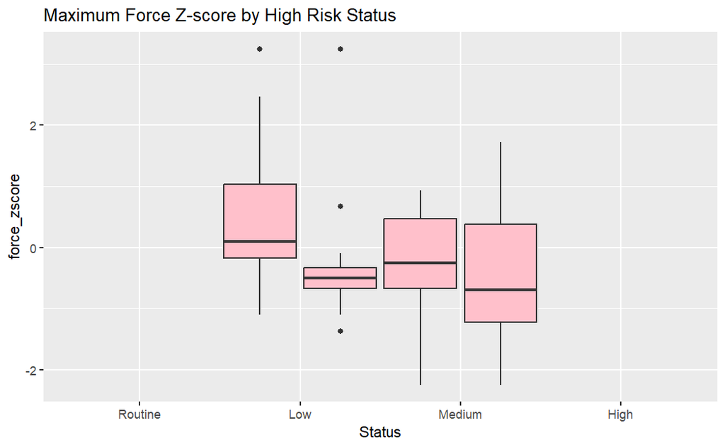

```r
#look at boxplots for visual comparison
ggplot(data=thresh_final, aes(x=Status, y=force_zscore))+
  geom_smooth() +
  geom_boxplot(width=2, fill="pink")+
  labs(title="Maximum Force Z-score by High Risk Status")
```

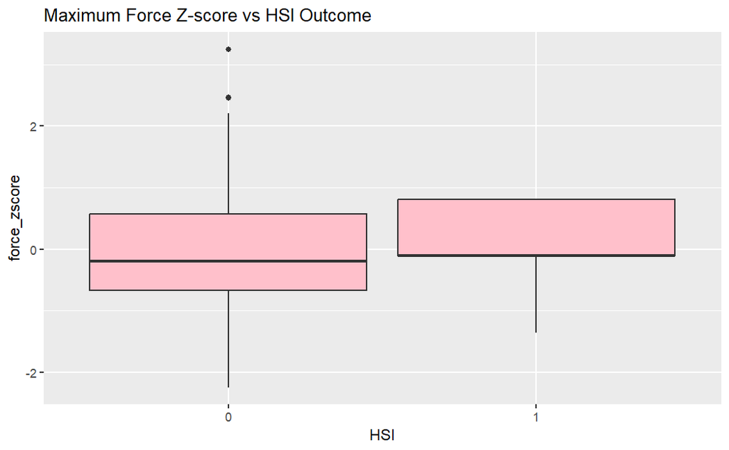

```r
ggplot(data=thresh_final, aes(x=HSI, y=force_zscore))+
  geom_boxplot(width=2, fill="pink")+
  labs(title="Maximum Force Z-score vs HSI Outcome")
```

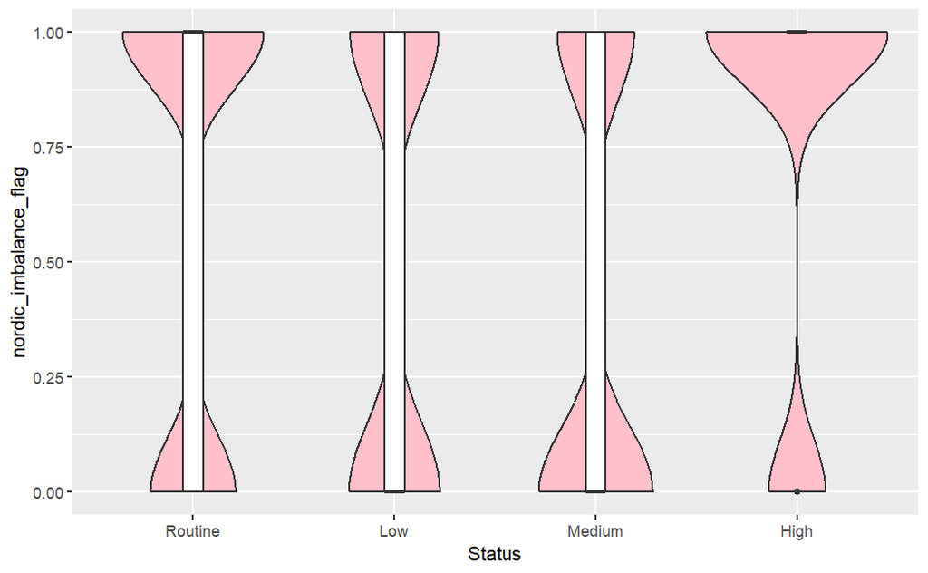

```r
#Imbalance
ggplot(data=thresh_final, aes(x =Status, y = nordic_imbalance_flag)) +
  geom_violin(fill = "pink") +
  geom_boxplot(width = 0.1)
```

```r
#LOOP THROUGH ALL POSITIONS TO CREATE THRESHOLDS OF EACH METRIC TAKING POSITION UNDER CONSIDERATION
positions <- unique(thresh_final$Position)
metrics <- c("Avg.Nordic.Left.Z.Score","Avg.Nordic.Right.Z.Score","nordic_zscore", "force_zscore", "recurrence_flag", "mechanism_flag","nordic_imbalance_score")

for (pos in positions){
    pos_data <- subset(thresh_final, Position == pos)
  pos_data$HighFlag <- ifelse(pos_data$Status == "High", "High", "Other")

  cat("\n====== Position:", pos, "======\n")

  for (metric in metrics) {
    cat("\n--- Metric:", metric, "---\n")

    high_group <- pos_data[pos_data$HighFlag == "High", ]
    injured_group <- pos_data[pos_data$HSI == 1, ]

    #quantiles for high-risk group
    cat("High-risk quantiles:\n")
    print(quantile(high_group[[metric]], probs = c(0.1, 0.25, 0.5, 0.75), na.rm = TRUE))

   #quantiles for injured group
    cat("Injured group quantiles:\n")
    print(quantile(injured_group[[metric]], probs = c(0.1, 0.25, 0.5, 0.75), na.rm = TRUE))

    #ROC analysis
 if (sum(!is.na(pos_data[[metric]])) > 20 &&
    length(unique(na.omit(pos_data$HSI))) == 2) {
    library(pROC)
    roc_obj <- roc(pos_data$HSI, pos_data[[metric]], direction = "<", quiet = TRUE)
    coords_best <- coords(roc_obj, "best", ret = c("threshold", "sensitivity", "specificity"))
    cat("ROC Best Threshold:", coords_best["threshold"], "\n")
} else {
    cat("Skipping ROC analysis: insufficient data or only one class present in HSI.\n")
}
  }
}
```

```
====== Position: DB ======

--- Metric: Avg.Nordic.Left.Z.Score ---
High-risk quantiles:
       10%        25%        50%        75%
-0.2042857 -0.2042857 -0.2042857  0.6310000
Injured group quantiles:
10% 25% 50% 75%
 NA  NA  NA  NA
Skipping ROC analysis: insufficient data or only one class present in HSI.

--- Metric: Avg.Nordic.Right.Z.Score ---
High-risk quantiles:
        10%         25%         50%         75%
-0.02285714 -0.02285714 -0.02285714  0.27600000
Injured group quantiles:
10% 25% 50% 75%
 NA  NA  NA  NA
Skipping ROC analysis: insufficient data or only one class present in HSI.

--- Metric: nordic_zscore ---
High-risk quantiles:
      10%       25%       50%       75%
0.4087894 0.4087894 0.4087894 0.4087894
Injured group quantiles:
10% 25% 50% 75%
 NA  NA  NA  NA
Skipping ROC analysis: insufficient data or only one class present in HSI.

--- Metric: force_zscore ---
High-risk quantiles:
       10%        25%        50%        75%
-2.2493534 -2.2493534 -0.4950768 -0.4950768
Injured group quantiles:
10% 25% 50% 75%
 NA  NA  NA  NA
Skipping ROC analysis: insufficient data or only one class present in HSI.

--- Metric: recurrence_flag ---
High-risk quantiles:
```

[output cut: 85 more lines]

```
Injured group quantiles:
10% 25% 50% 75%
 NA  NA  NA  NA
Skipping ROC analysis: insufficient data or only one class present in HSI.

====== Position: LB ======

--- Metric: Avg.Nordic.Left.Z.Score ---
High-risk quantiles:
       10%        25%        50%        75%
-0.7100000 -0.2940000 -0.1714286 -0.0200000
Injured group quantiles:
       10%        25%        50%        75%
-0.1714286 -0.1714286 -0.1714286 -0.1714286
ROC Best Threshold:
```

```
Error in cat("ROC Best Threshold:", coords_best["threshold"], "\n") :
  argument 2 (type 'list') cannot be handled by 'cat'
```

```r
#multimetric Threshold Matrix -create a risk score by counting how many thresholds an athlete breaches
thresh_final <- thresh_final %>%
  mutate(
    risk_score = as.numeric(nordic_imbalance_flag) +
                 as.numeric(recurrence_flag) +
                 as.numeric(mechanism_flag) +
                 as.numeric(nordic_zscore) +
                 as.numeric(force_zscore)
  )
#then logistic model
model_score <- glm(HSI ~ risk_score, data = thresh_final, family = "binomial")
summary(model_score)
```

```
Call:
glm(formula = HSI ~ risk_score, family = "binomial", data = thresh_final)

Coefficients:
            Estimate Std. Error z value Pr(>|z|)
(Intercept) -3.40378    0.32753 -10.392   <2e-16 ***
risk_score  -0.01516    0.13937  -0.109    0.913
---
Signif. codes:  0 ‘***’ 0.001 ‘**’ 0.01 ‘*’ 0.05 ‘.’ 0.1 ‘ ’ 1

(Dispersion parameter for binomial family taken to be 1)

    Null deviance: 445.18  on 1602  degrees of freedom
Residual deviance: 445.17  on 1601  degrees of freedom
  (95 observations deleted due to missingness)
AIC: 449.17

Number of Fisher Scoring iterations: 6
```

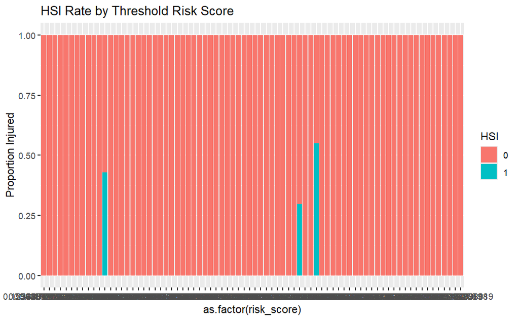

```r
# Plot injury probability by score
ggplot(thresh_final, aes(x = as.factor(risk_score), fill = HSI)) +
  geom_bar(position = "fill") +
  labs(title = "HSI Rate by Threshold Risk Score", y = "Proportion Injured")
```

```r
#Export Athletes Who Trigger Flags thru risk score
flagged_athletes <- thresh_final %>%
  filter(risk_score >= 3.5) %>%
  mutate(
    Avg.Nordic.Left.Z.Score = as.numeric(Avg.Nordic.Left.Z.Score),
    Avg.Nordic.Right.Z.Score = as.numeric(Avg.Nordic.Right.Z.Score),
    nordic_zscore = as.numeric(nordic_zscore),
    force_zscore = as.numeric(force_zscore)
        ) %>%
  select(anon_id, Position, Status, risk_score, Date,HSI)

#export a file of at risk athletes
write_csv(flagged_athletes, "flagged_athletes.csv")
```

```r
min(thresh_final$Date, na.rm=TRUE)  # june, 27, 2024
```

```
[1] "2024-06-27"
```

```r
max(thresh_final$Date, na.rm=TRUE)
```

```
[1] "2025-04-23"
```

```r
min(flagged_athletes$Date, na.rm=TRUE)  # june, 27, 2024
```

```
[1] "2024-06-27"
```

```r
max(flagged_athletes$Date, na.rm=TRUE)  # febuary,27, 2025
```

```
[1] "2025-02-27"
```

```r
#AROUND 1 year looking back of data, did not sort exaclty to that tho
```

-Dealing w/ Class Imbalances

```r
#demonstration of class imbalance that needs to be addressed
table(final_merge_full$HSI,final_merge_full$Status)
```

```
    High Low Medium Routine
  0   22  20     20      75
```

NOTE: HSI events are more rare causing a class in balance (majority class== no injury), can lead to misleading data

## Dashboard Recreation

```r
#merges the incident report and risk status by group (period of time) and player id
dash <- merge(merge_incid, merge_risk, by = c('anon_id', 'Group'), all = TRUE)

#merges the vald dataset by the same columns
dash <- merge(dash, merge_vald, by = c('anon_id', 'Group'), all = TRUE)

#merges the lower body injuries and a column for if a different HSI occurred (same leg or different leg) before the possible injury
dash <- merge(dash, merge_lower1, by = c('anon_id', 'Group'), all = TRUE)

#fills in most of the NAs with character stings and converts HSI to a binary indicator variable. Also selects just the variables within the soft tissue watch list as well as the previous HSI variable
dash <- dash %>%
  mutate(Group = ifelse(is.na(Group), 0, Group),
         Mechanism = ifelse(is.na(Mechanism), 'None', Mechanism),
         Prev.Injuries = ifelse(is.na(Final.Diagnosis), 'None', Final.Diagnosis),
         Time.Injured = ifelse(is.na(Time.Injured), 0, Time.Injured),
         OSICS14.Code = ifelse(is.na(OSICS14.Code), 'None', OSICS14.Code),
         HSI = ifelse(Group > 0, 1, 0),
         Prev.HSI = ifelse(is.na(Prev.HSI), 0, Prev.HSI),
         Status = as.factor(ifelse(is.na(Status), 'None', Status))) %>%
  dplyr::select(anon_id, Position, Prev.Injuries, Prev.HSI, Perc.Diff.Norm, Nordic.Mean.Imbalance, Trend, Status, HSI) %>%
  mutate(Prev.Injury.Num = ifelse(Prev.Injuries == 'None', 0, sapply(strsplit(Prev.Injuries, " and "), length)))

#recreating the dataset without NAs for visualizations, should contain 178 observations
dash_final <- dash %>%
  na.omit() %>%
  mutate(Status = factor(Status, ordered=TRUE, levels = c("None", "Routine", "Low", "Medium", "High")))

#filtering for just the high risk evaluations
dash_high <- dash_final %>%
  filter(Status == 'High')

#filtering for just the low risk evaluations
dash_low <- dash_final %>%
  filter(Status == 'Low')
```

```r
#summarizes the avg measures for each level of status
dash_final %>%
  group_by(Status) %>%
  summarize(Avg.Perc.Diff.Norm = mean(Perc.Diff.Norm),
            Avg.Imbalance = mean(Nordic.Mean.Imbalance),
            Avg.Trend = mean(Trend),
            Previous.HSI = mean(as.numeric(Prev.HSI)),
            HSI.Occured = mean(HSI))
```

| Status | Avg.Perc.Diff.Norm | Avg.Imbalance | Avg.Trend | Previous.HSI | HSI.Occured |
| --- | --- | --- | --- | --- | --- |
| None | -7.7364006 | 10.014997 | -0.01790840 | 0.15094340 | 0.7830189 |
| Routine | -0.7069136 | 7.684359 | 0.14487179 | 0.01538462 | 0.6923077 |
| Low | -20.6449627 | 7.110784 | 0.30392157 | 0.00000000 | 0.7647059 |
| Medium | -17.9237819 | 10.532407 | 0.19629630 | 0.16666667 | 0.9444444 |
| High | -16.4819477 | 14.531083 | 0.02333333 | 0.40000000 | 0.7500000 |

There are often relatively large changes in the imbalance numbers of a player when comparing the number from HSI and when they are following a previous HSI. This makes intiutive sense but important to note it could go either way, decreasing the imbalance or increasing the imbalance depending on which side was injured.

ID_111 was deemed low risk on 8/6/2024 with the note of ‘Overall weakness’, then suffered HSI in left hamstring on 12/19/2024 and 01/24/2025. Then he was deemed routine risk on 2/27/2025 and suffered another HSI in left hamstring on 03/13/2025, then suffered HSI in his right hamstring on 04/01/2025. Why was he not given high risk on 2/27/2025? There is only VALD data prior to one injury and from before 6 months before first HSI. In between these times his percent difference from norm increased from -28.7810384 to -20.5366817 and imbalance increased from 3.6 to 4.6. While these are averaged values from possible many observations there is not a significant difference between these values and in percent difference from norm he actually got stronger (better).

ID_117 was deemed low risk on 08/06/2024 and suffered HSI in right hamstring on 02/03/2025. He had a previous HSI and two other lower body injuries, -19.1408103 percent difference from norm, greatly increased imbalance of 16.65 and positive strength trend.

ID_247 was deemed routine risk on 02/27/2025 and suffered HSI in right hamstring on 04/08/2025. No previous HSI or lower body injuries, -20.2436195 percent difference from norm, very little imbalance, and neutral strength trend.

ID_430 was deemed routine risk on 06/27/2024 and suffered HSI in right hamstring on 08/13/2024. No previous HSI or lower body injuries, very little percent difference from norm, very little imbalance, and nuetral strength trend.

ID_50 was deemed routine risk on 06/27/2024 and suffered HSI in left hamstring on 07/28/2024. No previous HSI or lower body injuries, 15.4972015 percent difference from norm, very little imbalance, and also nuetral strength trend.

ID_485 (Tendon Injury) was deemed routine risk on 08/06/2024 and hurt hamstring tendon on 9/14/2024. Had a previous knee injury, 12.4102612 percent difference from norm, 9.36 mean imbalance and slightly positive strength trend.

ID_75 was deemed routine risk on 06/27/2024 and suffered HSI in right hamstring on 10/12/2024. He had a previous HSI and a right quadriceps injury, 34.3498134 percent difference from norm, 9.05 mean imbalance and slightly negative strength trend.

### Prevalance of HSI in Both Populations:

From down below we know that HSI occured after being deemed high risk in 7 of 33 athletes (0.2121212).

```r
#creates a list of all the unique anon_ids from VALD dataset (contains the most unique players)
all_play <- unique(VALD$anon_id)

#creates a list of all players not deemed high risk by finding values in all_play that are not in high_risk
all_no_hr <- setdiff(all_play, high_risk)
```

```r
#creates a dataset of all the non-high risk athletes and summarizes the number of HSI that each unique player in dataset experienced
incident_nohr <- filtered_incident %>%
  filter(OSICS14.Code %in% hamstring_OSICS14, anon_id %in% all_no_hr) %>%
  group_by(anon_id, Date.of.Injury...Onset.of.symptoms) %>%
  mutate(Total.Time.Injured = sum(Total.Time.Injured, na.rm = TRUE),
         Date = as.Date(Date.of.Injury...Onset.of.symptoms, format = '%m/%d/%Y')) %>%
  ungroup() %>%
  group_by(across(everything())) %>%
  summarise(.groups = 'drop') %>%
  group_by(anon_id) %>%
  summarize(count = n())

#creates a dataset of all the athletes and summarizes the number of HSI that each unique player in dataset experienced
incident_all <- filtered_incident %>%
  filter(OSICS14.Code %in% hamstring_OSICS14, anon_id %in% all_play) %>%
  group_by(anon_id, Date.of.Injury...Onset.of.symptoms) %>%
  mutate(Total.Time.Injured = sum(Total.Time.Injured, na.rm = TRUE),
         Date = as.Date(Date.of.Injury...Onset.of.symptoms, format = '%m/%d/%Y')) %>%
  ungroup() %>%
  group_by(across(everything())) %>%
  summarise(.groups = 'drop') %>%
  group_by(anon_id) %>%
  summarize(count = n())
```

Using the number of rows within these datasets above we can determine the number of unique athletes that suffered HSI within each population.

In the whole population there are 268 athletes and only 38 unique instances of HSI which is (0.141791).

### Fisher Test:

```r
#creates a 2x2 matrix of the with numbers of players who experienced HSI on left and players who did not on right with rows representing high risk players vs all players (population)
table_1 <- matrix(c(7, 33 - 7, nrow(incident_all), length(all_play) - nrow(incident_all)), nrow = 2, byrow = TRUE)

#creates a 2x2 matrix of the with numbers of players who experienced HSI on left and players who did not on right with rows representing high risk players vs not high risk players
table_2 <- matrix(c(7, 33 - 7, nrow(incident_nohr), length(all_no_hr) - nrow(incident_nohr)), nrow = 2, byrow = TRUE)

#carries out a fisher test to test for statistically significant difference in prevalance of HSI in each population, 'greater' makes it one sided and we are assuming that the prevalance of HSI within high risk should be greater
fisher.test(table_1, alternative = 'greater')
```

```
    Fisher's Exact Test for Count Data

data:  table_1
p-value = 0.1411
alternative hypothesis: true odds ratio is greater than 1
95 percent confidence interval:
 0.7446401       Inf
sample estimates:
odds ratio
  1.848539
```

```r
fisher.test(table_2, alternative = 'greater')
```

```
    Fisher's Exact Test for Count Data

data:  table_2
p-value = 0.003915
alternative hypothesis: true odds ratio is greater than 1
95 percent confidence interval:
 1.811273      Inf
sample estimates:
odds ratio
  4.955728
```

However, once again, 19 of these tests were done on 02/27/25 or later and the incident report only goes until April 22, 2025 so there could have been more injuries that occured afterwards unkown to us.

### Prevalances of Other Measures by Position (All Time):

```r
#creates new variables within VALD that show if a player experienced HSI or was deemed high risk ever as binary indicators, makes a trend variable that is numerical
Vald_prev <- Vald %>%
  mutate(HR = ifelse(anon_id %in% high_risk, 1, 0),
         HSI = ifelse(anon_id %in% players_HSI, 1, 0),
         Trend.Num = ifelse(Trend == 'Neutral', 0, ifelse(Trend == 'Up', 1, -1)))

#summarizes the prevalances of HSI within the positions for observations within VALD
Vald_prev %>%
  group_by(Position) %>%
  summarize(mean(HSI))
```

| Position | mean(HSI) |
| --- | --- |
| DB | 0.41624365 |
| DL | 0.13888889 |
| LB | 0.39506173 |
| OL | 0.41116751 |
| QB | 0.50000000 |
| RB | 0.90196078 |
| Specialist | 0.07547170 |
| TE | 0.48648649 |
| WR | 0.54216867 |
| NA | 0.03405573 |

Important to note that 90% of the observations in VALD that are RBs suffered HSI.

```r
#creates subsets of this above dataset filtered by positions
QBs <- Vald_prev %>%
  filter(Position == 'QB')
RBs <- Vald_prev %>%
  filter(Position == 'RB')
WRs <- Vald_prev %>%
  filter(Position == 'WR')
TEs <- Vald_prev %>%
  filter(Position == 'TE')
OLs <- Vald_prev %>%
  filter(Position == 'OL')
DBs <- Vald_prev %>%
  filter(Position == 'DB')
LBs <- Vald_prev %>%
  filter(Position == 'LB')
DLs <- Vald_prev %>%
  filter(Position == 'DL')
```

Important to note that no specialists were deemed high risk so leaving them out.

### 1. Nordic Mean Imbalance

```r
#carries out t.tests to analyze if there is statistical evidence of a difference within the position groups in mean imbalance (nordic). In terms of high risk status
#t.test(Nordic.MEAN.Imbalance ~ HR, data = QBs)
t.test(Nordic.MEAN.Imbalance ~ HR, data = RBs, alternative = 'less')
```

```
    Welch Two Sample t-test

data:  Nordic.MEAN.Imbalance by HR
t = -3.3843, df = 41.71, p-value = 0.0007819
alternative hypothesis: true difference in means between group 0 and group 1 is less than 0
95 percent confidence interval:
      -Inf -4.293757
sample estimates:
mean in group 0 mean in group 1
         5.4000         13.9375
```

```r
t.test(Nordic.MEAN.Imbalance ~ HR, data = WRs, alternative = 'less')
```

```
    Welch Two Sample t-test

data:  Nordic.MEAN.Imbalance by HR
t = -6.7913, df = 103.5, p-value = 3.6e-10
alternative hypothesis: true difference in means between group 0 and group 1 is less than 0
95 percent confidence interval:
      -Inf -7.707419
sample estimates:
mean in group 0 mean in group 1
       6.043243       16.243478
```

```r
#t.test(Nordic.MEAN.Imbalance ~ HR, data = TEs)
#t.test(Nordic.MEAN.Imbalance ~ HR, data = OLs)
t.test(Nordic.MEAN.Imbalance ~ HR, data = DBs, alternative = 'less')
```

```
    Welch Two Sample t-test

data:  Nordic.MEAN.Imbalance by HR
t = -3.6028, df = 49.394, p-value = 0.000365
alternative hypothesis: true difference in means between group 0 and group 1 is less than 0
95 percent confidence interval:
      -Inf -5.802966
sample estimates:
mean in group 0 mean in group 1
       9.758696       20.610811
```

```r
t.test(Nordic.MEAN.Imbalance ~ HR, data = LBs, alternative = 'less')
```

```
    Welch Two Sample t-test

data:  Nordic.MEAN.Imbalance by HR
t = -3.9562, df = 22.743, p-value = 0.0003189
alternative hypothesis: true difference in means between group 0 and group 1 is less than 0
95 percent confidence interval:
     -Inf -5.83742
sample estimates:
mean in group 0 mean in group 1
       6.834091       17.136842
```

```r
#t.test(Nordic.MEAN.Imbalance ~ HR, data = DLs)
```

In terms of avg imbalance RBs, WRs, DBs, and LBs are statistically significant.

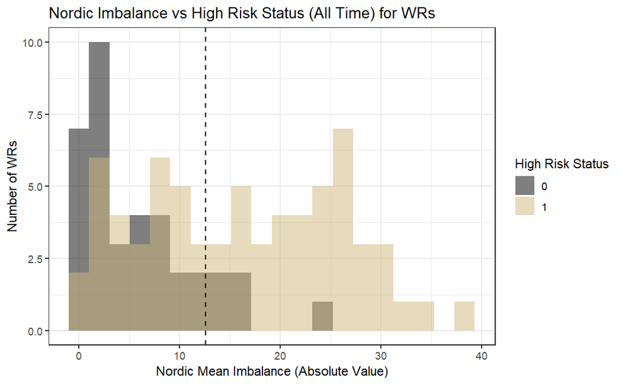

```r
#creates a histogram of nordic mean imbalance for WRs filled by high risk status, position = 'identity' argument makes it so the bars do not stack and the vertical line is the example threshold found above
ggplot(WRs, aes(Nordic.MEAN.Imbalance, fill = as.factor(HR))) +
  geom_histogram(position = 'identity', alpha = 0.5, bins = 20) +
  scale_fill_manual(values = c('black', '#CFB87C')) +
  labs(title = 'Nordic Imbalance vs High Risk Status (All Time) for WRs',
       x = 'Nordic Mean Imbalance (Absolute Value)',
       y = 'Number of WRs',
       fill = 'High Risk Status') +
  geom_vline(xintercept = 12.5772, col = 'black', linetype = 'dashed') +
  theme_bw()
```

### 2. Percent Difference from Norm

```r
#carries out t.tests to analyze if there is statistical evidence of a difference within the position groups in percent difference from norm (nordic). In terms of high risk status
#t.test(Perc.Diff.Norm ~ HR, data = QBs)
#t.test(Perc.Diff.Norm ~ HR, data = RBs)
t.test(Perc.Diff.Norm ~ HR, data = WRs, alternative = 'greater')
```

```
    Welch Two Sample t-test

data:  Perc.Diff.Norm by HR
t = 2.9895, df = 92.665, p-value = 0.001789
alternative hypothesis: true difference in means between group 0 and group 1 is greater than 0
95 percent confidence interval:
 3.488009      Inf
sample estimates:
mean in group 0 mean in group 1
      -8.732488      -16.584169
```

```r
t.test(Perc.Diff.Norm ~ HR, data = TEs, alternative = 'less')
```

```
    Welch Two Sample t-test

data:  Perc.Diff.Norm by HR
t = -2.9268, df = 30.948, p-value = 0.003184
alternative hypothesis: true difference in means between group 0 and group 1 is less than 0
95 percent confidence interval:
      -Inf -8.574857
sample estimates:
mean in group 0 mean in group 1
      -6.273834       14.110755
```

```r
t.test(Perc.Diff.Norm ~ HR, data = OLs, alternative = 'greater')
```

```
    Welch Two Sample t-test

data:  Perc.Diff.Norm by HR
t = 2.8575, df = 81.174, p-value = 0.002712
alternative hypothesis: true difference in means between group 0 and group 1 is greater than 0
95 percent confidence interval:
 4.446132      Inf
sample estimates:
mean in group 0 mean in group 1
      -3.147893      -13.791718
```

```r
t.test(Perc.Diff.Norm ~ HR, data = DBs, alternative = 'greater')
```

```
    Welch Two Sample t-test

data:  Perc.Diff.Norm by HR
t = 2.8853, df = 81.574, p-value = 0.0025
alternative hypothesis: true difference in means between group 0 and group 1 is greater than 0
95 percent confidence interval:
 4.156607      Inf
sample estimates:
mean in group 0 mean in group 1
      -11.21050       -21.02827
```

```r
t.test(Perc.Diff.Norm ~ HR, data = LBs, alternative = 'greater')
```

```
    Welch Two Sample t-test

data:  Perc.Diff.Norm by HR
t = 3.3094, df = 73.928, p-value = 0.0007234
alternative hypothesis: true difference in means between group 0 and group 1 is greater than 0
95 percent confidence interval:
 4.156679      Inf
sample estimates:
mean in group 0 mean in group 1
      -14.64791       -23.01696
```

```r
t.test(Perc.Diff.Norm ~ HR, data = DLs, alternative = 'greater')
```

```
    Welch Two Sample t-test

data:  Perc.Diff.Norm by HR
t = 4.158, df = 29.894, p-value = 0.0001241
alternative hypothesis: true difference in means between group 0 and group 1 is greater than 0
95 percent confidence interval:
 16.82392      Inf
sample estimates:
mean in group 0 mean in group 1
       5.610945      -22.819469
```

Significant: WRs, TEs, OLs, DBs, LBs, DLs

### 3. Strength Trend

```r
#carries out t.tests to analyze if there is statistical evidence of a difference within the position groups in trend as numeric. In terms of high risk status
t.test(Trend.Num ~ HR, data = QBs, alternative = 'greater')
```

```
    Welch Two Sample t-test

data:  Trend.Num by HR
t = 2.6057, df = 43, p-value = 0.006273
alternative hypothesis: true difference in means between group 0 and group 1 is greater than 0
95 percent confidence interval:
 0.09677435        Inf
sample estimates:
mean in group 0 mean in group 1
      0.2727273       0.0000000
```

```r
#t.test(Trend.Num ~ HR, data = RBs)
#t.test(Trend.Num ~ HR, data = WRs)
#t.test(Trend.Num ~ HR, data = TEs)
#t.test(Trend.Num ~ HR, data = OLs)
t.test(Trend.Num ~ HR, data = DBs, alternative = 'greater')
```

```
    Welch Two Sample t-test

data:  Trend.Num by HR
t = 2.1253, df = 166.53, p-value = 0.01752
alternative hypothesis: true difference in means between group 0 and group 1 is greater than 0
95 percent confidence interval:
 0.04928713        Inf
sample estimates:
mean in group 0 mean in group 1
     0.31531532      0.09302326
```

```r
#t.test(Trend.Num ~ HR, data = LBs)
t.test(Trend.Num ~ HR, data = DLs, alternative = 'greater')
```

```
    Welch Two Sample t-test

data:  Trend.Num by HR
t = 4.1692, df = 46.053, p-value = 6.674e-05
alternative hypothesis: true difference in means between group 0 and group 1 is greater than 0
95 percent confidence interval:
 0.3335055       Inf
sample estimates:
mean in group 0 mean in group 1
      0.3818182      -0.1764706
```

Trend only is significant for high risk in DLs, DBs, QBs